# TP – Systèmes de recommandation (v2 complet : système retenu (30, 10))

**Cours** : INF5063 – Machine learning : applications (G. Nollet, L. Benedetti) **Auteur** : Alban Rouault

Objectif : concevoir et évaluer un système de recommandation de films par filtrage collaboratif *user-based* sur le jeu de données Kaggle [The Movies Dataset](https://www.kaggle.com/datasets/rounakbanik/the-movies-dataset).

> **Version 2.** Le réglage retenu est choisi par la règle « à un écart-type » avec la variété en second critère, soit (30, 10), au lieu du maximum du NDCG moyen (50, 15) de la version 1. Les cellules de code, tableaux, figures et réponses des exercices 4 et 5 sont recalculés et rédigés pour ce réglage ; la section « Compléments » de l'exercice 4 détaille le choix.

## Imports et configuration

Toutes les dépendances sont déclarées dans `pyproject.toml` et gérées avec `uv` (`uv run jupyter lab` pour lancer le notebook).

```python
%load_ext autoreload
%autoreload 2

import inspect
from pathlib import Path

import matplotlib.pyplot as plt
import numpy as np
import pandas as pd

from donnees import split_par_utilisateur, parts_validation_croisee   # séparations (donnees.py)
from modeles import RecoUserBased, RecoItemBased   # modèles (modeles.py)
from evaluation import predire_test, rmse_mae, evaluer_modele, evaluer_populaire   # métriques (evaluation.py)

# Affichage des DataFrames
pd.set_option("display.max_columns", 30)
pd.set_option("display.width", 160)
pd.set_option("display.max_colwidth", 60)

# Reproductibilité : graine de tous les tirages aléatoires (chaque cellule qui tire crée son propre générateur)
RANDOM_STATE = 42

# Emplacement des données
DATA_DIR = Path("Ressources/dataset")
```

## Exercice 1 – Chargement des données

### 1) Chargement des fichiers

> Récupérer sur Kaggle et charger les fichiers suivants du dataset : `movies_metadata.csv`, `ratings_small.csv` et `links_small.csv`.

```python
movies = pd.read_csv(DATA_DIR / "movies_metadata.csv", low_memory=False)
ratings = pd.read_csv(DATA_DIR / "ratings_small.csv")
links = pd.read_csv(DATA_DIR / "links_small.csv")

tables = {"movies_metadata": movies, "ratings_small": ratings, "links_small": links}
for name, df in tables.items():
    print(f"{name:<16} {df.shape[0]:>7,} lignes  x {df.shape[1]:>2} colonnes")
```

```
movies_metadata   45,466 lignes  x 24 colonnes
ratings_small    100,004 lignes  x  4 colonnes
links_small        9,125 lignes  x  3 colonnes
```

**Réponse.** Les trois fichiers viennent de [The Movies Dataset](https://www.kaggle.com/datasets/rounakbanik/the-movies-dataset) (Kaggle) et sont dans `Ressources/dataset/`. `movies_metadata.csv` est lu avec `low_memory=False` : quelques lignes mal formées mélangent les types, on les traite à la question 5.

### 2) Aperçu des tables

> Afficher un aperçu de chaque table et vérifier leur compréhension.

```python
for name, df in tables.items():
    print(f"── {name} : {df.shape[0]:,} lignes x {df.shape[1]} colonnes")
    display(df.head(3))
```

```
── movies_metadata : 45,466 lignes x 24 colonnes
```

|  | adult | belongs_to_collection | budget | genres | homepage | id | imdb_id | original_language | original_title | overview | popularity | poster_path | production_companies | production_countries | release_date | revenue | runtime | spoken_languages | status | tagline | title | video | vote_average | vote_count |
| --- | --- | --- | --- | --- | --- | --- | --- | --- | --- | --- | --- | --- | --- | --- | --- | --- | --- | --- | --- | --- | --- | --- | --- | --- |
| 0 | False | {'id': 10194, 'name': 'Toy Story Collection', 'poster_pa... | 30000000 | [{'id': 16, 'name': 'Animation'}, {'id': 35, 'name': 'Co... | http://toystory.disney.com/toy-story | 862 | tt0114709 | en | Toy Story | Led by Woody, Andy's toys live happily in his room until... | 21.946943 | /rhIRbceoE9lR4veEXuwCC2wARtG.jpg | [{'name': 'Pixar Animation Studios', 'id': 3}] | [{'iso_3166_1': 'US', 'name': 'United States of America'}] | 1995-10-30 | 373554033.0 | 81.0 | [{'iso_639_1': 'en', 'name': 'English'}] | Released | NaN | Toy Story | False | 7.7 | 5415.0 |
| 1 | False | NaN | 65000000 | [{'id': 12, 'name': 'Adventure'}, {'id': 14, 'name': 'Fa... | NaN | 8844 | tt0113497 | en | Jumanji | When siblings Judy and Peter discover an enchanted board... | 17.015539 | /vzmL6fP7aPKNKPRTFnZmiUfciyV.jpg | [{'name': 'TriStar Pictures', 'id': 559}, {'name': 'Teit... | [{'iso_3166_1': 'US', 'name': 'United States of America'}] | 1995-12-15 | 262797249.0 | 104.0 | [{'iso_639_1': 'en', 'name': 'English'}, {'iso_639_1': '... | Released | Roll the dice and unleash the excitement! | Jumanji | False | 6.9 | 2413.0 |
| 2 | False | {'id': 119050, 'name': 'Grumpy Old Men Collection', 'pos... | 0 | [{'id': 10749, 'name': 'Romance'}, {'id': 35, 'name': 'C... | NaN | 15602 | tt0113228 | en | Grumpier Old Men | A family wedding reignites the ancient feud between next... | 11.7129 | /6ksm1sjKMFLbO7UY2i6G1ju9SML.jpg | [{'name': 'Warner Bros.', 'id': 6194}, {'name': 'Lancast... | [{'iso_3166_1': 'US', 'name': 'United States of America'}] | 1995-12-22 | 0.0 | 101.0 | [{'iso_639_1': 'en', 'name': 'English'}] | Released | Still Yelling. Still Fighting. Still Ready for Love. | Grumpier Old Men | False | 6.5 | 92.0 |

```
── ratings_small : 100,004 lignes x 4 colonnes
```

|  | userId | movieId | rating | timestamp |
| --- | --- | --- | --- | --- |
| 0 | 1 | 31 | 2.5 | 1260759144 |
| 1 | 1 | 1029 | 3.0 | 1260759179 |
| 2 | 1 | 1061 | 3.0 | 1260759182 |

```
── links_small : 9,125 lignes x 3 colonnes
```

|  | movieId | imdbId | tmdbId |
| --- | --- | --- | --- |
| 0 | 1 | 114709 | 862.0 |
| 1 | 2 | 113497 | 8844.0 |
| 2 | 3 | 113228 | 15602.0 |

```python
def resume_colonnes(df: pd.DataFrame) -> pd.DataFrame:
    """Type, remplissage et cardinalité de chaque colonne."""
    return pd.DataFrame({
        "type": df.dtypes.astype(str),
        "% nuls": (df.isna().mean() * 100).round(1),
        "valeurs distinctes": df.nunique(),
        "exemple": df.iloc[0].astype(str).str.slice(0, 40),
    })

resume_colonnes(movies)
```

|  | type | % nuls | valeurs distinctes | exemple |
| --- | --- | --- | --- | --- |
| adult | str | 0.0 | 5 | False |
| belongs_to_collection | str | 90.1 | 1698 | {'id': 10194, 'name': 'Toy Story Collect |
| budget | str | 0.0 | 1226 | 30000000 |
| genres | str | 0.0 | 4069 | [{'id': 16, 'name': 'Animation'}, {'id': |
| homepage | str | 82.9 | 7673 | http://toystory.disney.com/toy-story |
| id | str | 0.0 | 45436 | 862 |
| imdb_id | str | 0.0 | 45417 | tt0114709 |
| original_language | str | 0.0 | 92 | en |
| original_title | str | 0.0 | 43373 | Toy Story |
| overview | str | 2.1 | 44307 | Led by Woody, Andy's toys live happily i |
| popularity | str | 0.0 | 43758 | 21.946943 |
| poster_path | str | 0.8 | 45024 | /rhIRbceoE9lR4veEXuwCC2wARtG.jpg |
| production_companies | str | 0.0 | 22708 | [{'name': 'Pixar Animation Studios', 'id |
| production_countries | str | 0.0 | 2393 | [{'iso_3166_1': 'US', 'name': 'United St |
| release_date | str | 0.2 | 17336 | 1995-10-30 |
| revenue | float64 | 0.0 | 6863 | 373554033.0 |
| runtime | float64 | 0.6 | 353 | 81.0 |
| spoken_languages | str | 0.0 | 1931 | [{'iso_639_1': 'en', 'name': 'English'}] |
| status | str | 0.2 | 6 | Released |
| tagline | str | 55.1 | 20283 | NaN |
| title | str | 0.0 | 42277 | Toy Story |
| video | object | 0.0 | 2 | False |
| vote_average | float64 | 0.0 | 92 | 7.7 |
| vote_count | float64 | 0.0 | 1820 | 5415.0 |

```python
print("Valeurs de rating :", sorted(ratings["rating"].unique().tolist()))
print("Période des avis  :",
      pd.to_datetime(ratings["timestamp"].min(), unit="s").date(), "->",
      pd.to_datetime(ratings["timestamp"].max(), unit="s").date())
print("Nuls dans ratings :", ratings.isna().sum().sum(), "| nuls dans links :", links.isna().sum().to_dict())
```

```
Valeurs de rating : [0.5, 1.0, 1.5, 2.0, 2.5, 3.0, 3.5, 4.0, 4.5, 5.0]
Période des avis  : 1995-01-09 -> 2016-10-16
Nuls dans ratings : 0 | nuls dans links : {'movieId': 0, 'imdbId': 0, 'tmdbId': 13}
```

**Réponse.**

**`movies_metadata`** – une ligne par film du catalogue TMDB (45 466 lignes).

| Colonne | Contenu |
| --- | --- |
| `id` | identifiant TMDB du film (clé) |
| `imdb_id` | identifiant IMDB (`tt0114709`) |
| `title`, `original_title` | titre (anglais) et titre original |
| `overview`, `tagline` | synopsis et phrase d'accroche |
| `genres` | liste de genres, stockée comme texte JSON |
| `release_date` | date de sortie |
| `runtime` | durée en minutes |
| `budget`, `revenue` | budget et recettes mondiales en dollars (0 = inconnu) |
| `popularity` | score de popularité TMDB |
| `vote_average`, `vote_count` | note moyenne sur 10 et nombre de votes sur TMDB |
| `original_language`, `spoken_languages` | langue d'origine (code ISO) et langues parlées |
| `production_companies`, `production_countries` | sociétés et pays de production (texte JSON) |
| `belongs_to_collection` | saga du film (Toy Story Collection…), vide dans 90 % des cas |
| `status` | Released, Post Production, Rumored… |
| `adult`, `video` | film pour adultes ; vidéo hors salle (rares) |
| `homepage`, `poster_path` | site officiel et chemin de l'affiche |

**`ratings_small`** – une ligne par avis (100 004 lignes).

| Colonne | Contenu |
| --- | --- |
| `userId` | identifiant de l'utilisateur (MovieLens) |
| `movieId` | identifiant du film (MovieLens, **différent** de l'id TMDB) |
| `rating` | note de 0,5 à 5 par pas de 0,5 |
| `timestamp` | date de l'avis (secondes Unix, de 1995 à 2016) |

**`links_small`** – une ligne par film du jeu réduit (9 125 lignes).

| Colonne | Contenu |
| --- | --- |
| `movieId` | identifiant MovieLens (celui de `ratings_small`) |
| `imdbId` | identifiant IMDB |
| `tmdbId` | identifiant TMDB (celui de `movies_metadata`), manquant pour 13 films |

À retenir : `ratings_small` est propre (aucun nul), alors que `movies_metadata` a des colonnes très peu remplies et des colonnes numériques lues comme du texte (`id`, `budget`, `popularity`) à cause de lignes mal formées.

### 3) Effectifs

> Combien d'utilisateurs y a-t-il ? De films ? D'avis ?

```python
n_users = ratings["userId"].nunique()
n_movies_rated = ratings["movieId"].nunique()
n_ratings = len(ratings)
avis_par_user = ratings.groupby("userId").size()

pd.DataFrame({
    "valeur": [n_users, n_ratings, n_movies_rated, links["movieId"].nunique(), movies["id"].nunique(),
               f"{avis_par_user.min()} / {avis_par_user.median():.0f} / {avis_par_user.max()}",
               f"{n_ratings / (n_users * n_movies_rated):.2%}",
               f"{(ratings['rating'] >= 4).mean():.0%}", (ratings.groupby("movieId").size() == 1).sum()],
}, index=["utilisateurs", "avis", "films notés", "films dans links_small", "films dans movies_metadata",
          "avis par utilisateur (min / médiane / max)", "densité de la matrice utilisateurs x films",
          "part des avis >= 4", "films notés une seule fois"])
```

|  | valeur |
| --- | --- |
| utilisateurs | 671 |
| avis | 100004 |
| films notés | 9066 |
| films dans links_small | 9125 |
| films dans movies_metadata | 45436 |
| avis par utilisateur (min / médiane / max) | 20 / 71 / 2391 |
| densité de la matrice utilisateurs x films | 1.64% |
| part des avis >= 4 | 52% |
| films notés une seule fois | 3063 |

**Réponse.**

| Utilisateurs | **671** |  |
| --- | --- | --- |
| Avis | **100 004** |  |
| Films notés | **9 066** | films ayant reçu au moins un avis dans `ratings_small` |

Pour situer ces 9 066 films, il existe deux autres périmètres :

| Films du jeu réduit | 9 125 | lignes de `links_small` : 59 films de plus, présents mais jamais notés |
| --- | --- | --- |
| Films du catalogue | 45 436 | ids distincts de `movies_metadata` avant nettoyage (45 433 après, question 5) : tout TMDB, dont 36 000 films hors du jeu réduit |

Le chiffre qui compte pour la suite est **9 066** : c'est le nombre de colonnes de la matrice utilisateurs × films avant séparation train/test (8 384 après, les films notés en train). Chaque utilisateur a noté au moins 20 films (médiane 71). La matrice n'est remplie qu'à **1,6 %** : elle est très creuse, ce sera la difficulté principale du filtrage collaboratif. Un tiers des films n'ont qu'un seul avis, et 52 % des notes sont ≥ 4 : les utilisateurs notent surtout ce qu'ils ont aimé.

### 4) Rôle de `links_small.csv`

> Quelle est l'utilité du fichier `links_small.csv` par rapport aux deux autres fichiers ?

```python
# Le film movieId = 1 dans ratings : quel est-il ?
tmdb_id = int(links.loc[links["movieId"] == 1, "tmdbId"].iloc[0])
print(f"ratings movieId = 1  ->  links tmdbId = {tmdb_id}  ->  movies_metadata :")
display(movies.loc[movies["id"] == str(tmdb_id), ["id", "imdb_id", "title", "release_date"]])

print("movieId de ratings absents de links :", (~ratings["movieId"].isin(links["movieId"])).sum())
print("Films de links sans tmdbId          :", links["tmdbId"].isna().sum())
print("tmdbId de links absents de metadata :",
      (~links["tmdbId"].dropna().astype(int).astype(str).isin(movies["id"])).sum())
```

```
ratings movieId = 1  ->  links tmdbId = 862  ->  movies_metadata :
```

|  | id | imdb_id | title | release_date |
| --- | --- | --- | --- | --- |
| 0 | 862 | tt0114709 | Toy Story | 1995-10-30 |

```
movieId de ratings absents de links : 0
Films de links sans tmdbId          : 13
tmdbId de links absents de metadata : 30
```

**Réponse.** Les avis utilisent des identifiants **MovieLens** (`movieId`), les métadonnées des identifiants **TMDB** (`id`) : les deux tables n'ont aucune clé commune. `links_small` est la **table de correspondance** qui permet de passer de l'un à l'autre, donc de retrouver le titre d'un film noté (`movieId` 1 → `tmdbId` 862 → *Toy Story*).

Limite : 13 films n'ont pas de `tmdbId` et 30 `tmdbId` sont absents du catalogue. Ces films pourront être notés et recommandés, mais pas affichés avec leur titre.

### 5) Nettoyage de `movies_metadata`

> Nettoyer la table `movies_metadata.csv` : convertir tous les ID de films au format numérique (en retirant les films dont les ID ne sont pas numériques), ne conserver qu'une ligne par ID unique.

Le nettoyage se fait en mémoire : le CSV n'est jamais modifié. On garde `movies` (brut) et on crée `movies_clean`.

```python
# 1. ID au format numérique : les valeurs non convertibles deviennent NaN
id_num = pd.to_numeric(movies["id"], errors="coerce")
print(f"Lignes dont l'id n'est pas numérique : {id_num.isna().sum()}")
display(movies.loc[id_num.isna(), ["adult", "budget", "id", "title", "release_date", "popularity", "revenue"]])
```

```
Lignes dont l'id n'est pas numérique : 3
```

|  | adult | budget | id | title | release_date | popularity | revenue |
| --- | --- | --- | --- | --- | --- | --- | --- |
| 19730 | - Written by Ørnås | /ff9qCepilowshEtG2GYWwzt2bs4.jpg | 1997-08-20 | NaN | 1 | NaN | NaN |
| 29503 | Rune Balot goes to a casino connected to the October co... | /zV8bHuSL6WXoD6FWogP9j4x80bL.jpg | 2012-09-29 | NaN | 12 | NaN | NaN |
| 35587 | Avalanche Sharks tells the story of a bikini contest th... | /zaSf5OG7V8X8gqFvly88zDdRm46.jpg | 2014-01-01 | NaN | 22 | Beware Of Frost Bites | NaN |

Ces trois lignes sont **décalées** : un morceau de synopsis dans `adult`, un chemin d'affiche dans `budget`, une date dans `id`, pas de titre. Elles sont inexploitables.

```python
# 2. Retrait de ces lignes et conversion en entier
movies_clean = movies.loc[id_num.notna()].copy()
movies_clean["id"] = id_num.loc[id_num.notna()].astype(int)

# 3. Doublons sur l'id
doublons = movies_clean[movies_clean.duplicated("id", keep=False)].sort_values("id")
print(f"Lignes en doublon sur l'id : {doublons['id'].duplicated().sum()} "
      f"({doublons['id'].nunique()} ids concernés, {doublons.duplicated().sum()} doublons strictement identiques)")

# Deux exemples : un doublon identique (105045) et un doublon qui diffère (4912)
display(doublons.loc[doublons["id"].isin([105045, 4912]),
                     ["id", "title", "release_date", "popularity", "vote_count", "revenue"]])

cols_diff = {c for _, g in doublons.groupby("id") for c in g.columns if g[c].astype(str).nunique() > 1}
print("Colonnes qui diffèrent entre doublons :", cols_diff)
```

```
Lignes en doublon sur l'id : 30 (29 ids concernés, 17 doublons strictement identiques)
```

|  | id | title | release_date | popularity | vote_count | revenue |
| --- | --- | --- | --- | --- | --- | --- |
| 5865 | 4912 | Confessions of a Dangerous Mind | 2002-12-30 | 11.331072 | 281.0 | 33013805.0 |
| 33826 | 4912 | Confessions of a Dangerous Mind | 2002-12-30 | 7.645827 | 281.0 | 33013805.0 |
| 1465 | 105045 | The Promise | 1995-02-16 | 0.122178 | 1.0 | 0.0 |
| 676 | 105045 | The Promise | 1995-02-16 | 0.122178 | 1.0 | 0.0 |

```
Colonnes qui diffèrent entre doublons : {'popularity', 'vote_count'}
```

```python
movies_clean = movies_clean.drop_duplicates("id", keep="first").reset_index(drop=True)

print(f"Avant : {len(movies):,} lignes  ->  après : {len(movies_clean):,} lignes")
print("id unique :", movies_clean["id"].is_unique, "| dtype :", movies_clean["id"].dtype)
```

```
Avant : 45,466 lignes  ->  après : 45,433 lignes
id unique : True | dtype : int64
```

**Réponse.** Deux opérations :

1. **3 lignes** ont un `id` non numérique (lignes décalées de l'export) : retirées, puis `id` converti en entier.
2. **30 lignes** sont en doublon (29 films, dont un exporté trois fois). 17 sont strictement identiques ; les autres ne diffèrent que par `popularity` et, pour deux films, `vote_count`, des compteurs qui bougent dans le temps : ce sont plusieurs exports du même film. On garde la première.

Résultat : **45 433 films**, un par `id` entier, joignable directement à `tmdbId` de `links_small`.

### 6) Nettoyage de `ratings_small`

> Nettoyer la table `ratings_small.csv` : retirer les avis manquants et les ID d'utilisateurs et de films non conformes, et convertir tous les ID d'utilisateurs et de films au format numérique.

Un avis est conforme si : la note est présente et sur l'échelle MovieLens (0,5 à 5 par pas de 0,5), les identifiants sont des entiers strictement positifs, et le couple (utilisateur, film) est unique.

```python
n_avant = len(ratings)
ratings_clean = ratings.copy()

# 1. Avis manquants
manquants = ratings_clean[["userId", "movieId", "rating"]].isna().any(axis=1)
print(f"Avis avec valeur manquante          : {manquants.sum()}")
ratings_clean = ratings_clean[~manquants]

# 2. Identifiants conformes -> entiers
for col in ["userId", "movieId"]:
    num = pd.to_numeric(ratings_clean[col], errors="coerce")
    conforme = num.notna() & (num > 0) & (num % 1 == 0)
    print(f"{col:<8} non conformes               : {(~conforme).sum()}")
    ratings_clean = ratings_clean[conforme].assign(**{col: num[conforme].astype(int)})

# 3. Notes conformes
note_ok = ratings_clean["rating"].between(0.5, 5) & ((ratings_clean["rating"] * 2) % 1 == 0)
print(f"Notes hors échelle MovieLens        : {(~note_ok).sum()}")
ratings_clean = ratings_clean[note_ok]

# 4. Doublons (utilisateur, film)
dup = ratings_clean.duplicated(["userId", "movieId"])
print(f"Doublons (userId, movieId)          : {dup.sum()}")
ratings_clean = ratings_clean[~dup].reset_index(drop=True)

# Films sans métadonnées (conservés : le filtrage collaboratif n'en a pas besoin)
sans_meta = ~ratings_clean["movieId"].isin(links.loc[links["tmdbId"].isin(movies_clean["id"]), "movieId"])
print(f"Avis sur un film sans métadonnées   : {sans_meta.sum()} (conservés)")

print(f"\nAvant : {n_avant:,} avis  ->  après : {len(ratings_clean):,} avis")
print(ratings_clean.dtypes.to_string())
```

[output not shown]

**Réponse.** `ratings_small` est déjà propre : aucun avis manquant, aucun identifiant non conforme, aucun doublon, et les identifiants sont déjà des entiers. Le code reste défensif pour fonctionner sur un fichier moins propre. Les **100 004 avis** sont conservés, y compris les 194 qui portent sur un film sans métadonnées : le filtrage collaboratif n'utilise que les notes.

### 7) Les 10 films les plus anciens

> Déterminer les 10 films les plus anciens du dataset.

```python
# Conversion de release_date en date ; les valeurs invalides deviennent NaT
movies_clean["release_date"] = pd.to_datetime(movies_clean["release_date"], errors="coerce")

print("Films sans date de sortie :", movies_clean["release_date"].isna().sum())
futur = movies_clean[movies_clean["release_date"] > "2017-12-31"]
print(f"Films datés après 2017 (extraction du dataset) : {len(futur)}")
display(futur[["id", "title", "release_date", "status", "vote_count"]])
```

```
Films sans date de sortie : 87
Films datés après 2017 (extraction du dataset) : 6
```

|  | id | title | release_date | status | vote_count |
| --- | --- | --- | --- | --- | --- |
| 26541 | 76600 | Avatar 2 | 2020-12-16 | In Production | 58.0 |
| 30379 | 38700 | Bad Boys for Life | 2018-11-07 | Planned | 12.0 |
| 33336 | 302349 | Iron Sky: The Coming Race | 2018-03-01 | Post Production | 0.0 |
| 38103 | 332283 | Mary Shelley | 2018-04-25 | Post Production | 1.0 |
| 38857 | 299782 | The Other Side of the Wind | 2018-12-31 | Post Production | 1.0 |
| 44505 | 412059 | Mobile Homes | 2018-04-04 | Post Production | 1.0 |

```python
cols = ["id", "title", "release_date", "runtime", "original_language", "vote_count"]
movies_clean.dropna(subset=["release_date"]).nsmallest(10, "release_date")[cols]
```

|  | id | title | release_date | runtime | original_language | vote_count |
| --- | --- | --- | --- | --- | --- | --- |
| 34915 | 315946 | Passage of Venus | 1874-12-09 | 1.0 | xx | 19.0 |
| 34912 | 194079 | Sallie Gardner at a Gallop | 1878-06-14 | 1.0 | en | 25.0 |
| 41572 | 426903 | Buffalo Running | 1883-11-19 | 1.0 | en | 7.0 |
| 34908 | 159897 | Man Walking Around a Corner | 1887-08-18 | 1.0 | xx | 17.0 |
| 34909 | 96882 | Accordion Player | 1888-01-01 | 1.0 | xx | 18.0 |
| 34913 | 16464 | Traffic Crossing Leeds Bridge | 1888-10-15 | 1.0 | xx | 25.0 |
| 34914 | 33316 | London's Trafalgar Square | 1890-01-01 | 1.0 | xx | 9.0 |
| 41164 | 386743 | Mosquinha | 1890-03-09 | 1.0 | en | 2.0 |
| 34910 | 32571 | Monkeyshines, No. 1 | 1890-11-21 | 1.0 | en | 15.0 |
| 34911 | 33315 | Monkeyshines, No. 2 | 1890-11-21 | 1.0 | xx | 12.0 |

**Réponse.** Anomalies repérées avant de trier : 87 films sans date, et 6 films datés de 2018 ou 2020, donc pas encore sortis quand le dataset a été extrait (2017).

Les 10 films les plus anciens vont de **1874** (*Passage of Venus*) à **1890** (*Monkeyshines*) : des films d'une minute des pionniers du cinéma, à l'époque des premières expériences de chronophotographie.

### 8) Les 10 plus gros succès au box-office

> Déterminer les 10 films ayant eu le plus gros succès au box-office (colonne `revenue`).

```python
movies_clean["revenue"] = pd.to_numeric(movies_clean["revenue"], errors="coerce")
rev = movies_clean["revenue"]

print(f"revenue manquant (NaN)  : {rev.isna().sum():>6,}")
print(f"revenue = 0             : {(rev == 0).sum():>6,}  ({(rev == 0).mean():.1%} des films)")
print(f"0 < revenue < 1 000     : {rev.between(1, 999).sum():>6,}")
print(f"revenue >= 1 000        : {(rev >= 1000).sum():>6,}")

# Exemples de valeurs suspectes : quelques dollars de recettes pour des films sortis en salle
display(movies_clean.loc[rev.between(1, 999), ["title", "release_date", "budget", "revenue"]].head(5))
```

```
revenue manquant (NaN)  :      3
revenue = 0             : 38,032  (83.7% des films)
0 < revenue < 1 000     :    154
revenue >= 1 000        :  7,244
```

|  | title | release_date | budget | revenue |
| --- | --- | --- | --- | --- |
| 87 | Black Sheep | 1996-02-01 | 0 | 32.0 |
| 114 | Anne Frank Remembered | 1995-06-08 | 0 | 1.0 |
| 180 | Mute Witness | 1995-09-28 | 2 | 1.0 |
| 185 | The Prophecy | 1995-09-01 | 8 | 16.0 |
| 274 | Miami Rhapsody | 1995-01-27 | 6 | 5.0 |

```python
top_revenue = movies_clean.nlargest(10, "revenue").copy()
top_revenue["revenue (M$)"] = (top_revenue["revenue"] / 1e6).round(0)
top_revenue["budget (M$)"] = (pd.to_numeric(top_revenue["budget"], errors="coerce") / 1e6).round(0)
top_revenue[["id", "title", "release_date", "revenue (M$)", "budget (M$)", "vote_average", "vote_count"]]
```

|  | id | title | release_date | revenue (M$) | budget (M$) | vote_average | vote_count |
| --- | --- | --- | --- | --- | --- | --- | --- |
| 14546 | 19995 | Avatar | 2009-12-10 | 2788.0 | 237.0 | 7.2 | 12114.0 |
| 26537 | 140607 | Star Wars: The Force Awakens | 2015-12-15 | 2068.0 | 245.0 | 7.5 | 7993.0 |
| 1638 | 597 | Titanic | 1997-11-18 | 1845.0 | 200.0 | 7.5 | 7770.0 |
| 17810 | 24428 | The Avengers | 2012-04-25 | 1520.0 | 220.0 | 7.4 | 12000.0 |
| 25066 | 135397 | Jurassic World | 2015-06-09 | 1514.0 | 150.0 | 6.5 | 8842.0 |
| 28811 | 168259 | Furious 7 | 2015-04-01 | 1506.0 | 190.0 | 7.3 | 4253.0 |
| 26540 | 99861 | Avengers: Age of Ultron | 2015-04-22 | 1405.0 | 280.0 | 7.3 | 6908.0 |
| 17429 | 12445 | Harry Potter and the Deathly Hallows: Part 2 | 2011-07-07 | 1342.0 | 125.0 | 7.9 | 6141.0 |
| 22096 | 109445 | Frozen | 2013-11-27 | 1274.0 | 150.0 | 7.3 | 5440.0 |
| 42192 | 321612 | Beauty and the Beast | 2017-03-16 | 1263.0 | 160.0 | 6.8 | 5530.0 |

**Réponse.** La colonne `revenue` est très incomplète : **84 % des films ont 0**, qui veut dire "inconnu", et 154 films affichent quelques dollars (unité fausse). Cela ne gêne pas le classement des plus gros succès, qui ne regarde que les grandes valeurs.

Le top 10 va d'**Avatar** (2,79 milliards de dollars) à **Beauty and the Beast** (1,26), en passant par *Star Wars : The Force Awakens*, *Titanic*, *The Avengers*, *Jurassic World* et *Furious 7*. Les recettes sont en dollars courants, non corrigées de l'inflation, d'où la domination des films récents.

### 9) Séparation entraînement / test

> Nous aurons besoin d'une séparation entraînement/test pour tester nos modèles. Que faut-il séparer en deux ? Effectuer une séparation entraînement/test de sorte à ce que chaque utilisateur en test ait une chance de recevoir de bonnes recommandations. Comment avez-vous fait ?

*Entraînement / test* : on cache une partie des avis (le **test**) et on construit le modèle sur le reste (le **train**). On juge ensuite le modèle sur sa capacité à retrouver ce qu'on lui a caché, comme un examen dont on connaît les réponses. *Stratifier* : tirer séparément dans chaque catégorie (ici films aimés / non aimés) pour que chaque catégorie soit représentée. *Graine aléatoire* : nombre qui fixe le tirage, pour retomber sur le même découpage à chaque exécution.

```python
SEUIL_PERTINENT = 4.0   # un film noté >= 4 est considéré comme "aimé" (servira aussi pour les métriques top k)
FRAC_TEST = 0.2

# La fonction de séparation est dans donnees.py ; on affiche sa source pour la lecture
print(inspect.getsource(split_par_utilisateur))

train, test = split_par_utilisateur(ratings_clean, FRAC_TEST, SEUIL_PERTINENT, RANDOM_STATE)
print(f"train : {len(train):>6,} avis ({len(train) / len(ratings_clean):.1%})")
print(f"test  : {len(test):>6,} avis ({len(test) / len(ratings_clean):.1%})")
```

```
def split_par_utilisateur(ratings, frac_test, seuil_pertinent, seed):
    """Sépare les AVIS en train/test, utilisateur par utilisateur.

    Pour chaque utilisateur, frac_test de ses avis partent en test, en stratifiant sur
    "film aimé (note >= seuil_pertinent) / non aimé" avec au moins un avis par strate.
    Chaque utilisateur garde ainsi la majorité de ses avis en train et a au moins un film aimé en test.
    Sert aussi à découper une validation dans train (exercice 4).
    """
    # Un seul générateur pour tous les groupes : réutiliser la même graine dans chaque
    # groupe ferait tirer les mêmes positions pour tous les groupes de même taille.
    rng = np.random.default_rng(seed)
    aime = ratings["rating"] >= seuil_pertinent
    strate = ratings["userId"].astype(str) + "_" + aime.astype(str)

    def tirer(groupe):
        n_test = max(1, round(len(groupe) * frac_test))   # au moins 1 avis par strate
        return groupe.sample(n=n_test, random_state=rng)

    test = ratings.groupby(strate, group_keys=False).apply(tirer, include_groups=False)
    train = ratings.drop(test.index)
    return train.reset_index(drop=True), test.reset_index(drop=True)
```

```
train : 79,976 avis (80.0%)
test  : 20,028 avis (20.0%)
```

```python
# Vérifications : chaque utilisateur est-il bien "testable" ?
par_user_train = train.groupby("userId").size()
par_user_test = test.groupby("userId").size()
aimes_test = test[test["rating"] >= SEUIL_PERTINENT].groupby("userId").size()

print(f"Utilisateurs en train / en test          : {train['userId'].nunique()} / {test['userId'].nunique()}")
print(f"Avis par utilisateur en train (min/méd.) : {par_user_train.min()} / {par_user_train.median():.0f}")
print(f"Avis par utilisateur en test  (min/méd.) : {par_user_test.min()} / {par_user_test.median():.0f}")
print(f"Utilisateurs sans film aimé en test      : {test['userId'].nunique() - len(aimes_test)}")
aimes_train = train[train["rating"] >= SEUIL_PERTINENT].groupby("userId").size()
print(f"Utilisateurs sans film aimé en train     : {train['userId'].nunique() - len(aimes_train)}",
      sorted(set(train["userId"]) - set(aimes_train.index)))
part_test = par_user_test / (par_user_train + par_user_test)
print(f"Part de test par utilisateur (min/méd/max): {part_test.min():.1%} / {part_test.median():.1%} / {part_test.max():.1%}")
print(f"Note moyenne train / test                : {train['rating'].mean():.3f} / {test['rating'].mean():.3f}")
print(f"Films aimés en test par utilisateur (méd.): {aimes_test.median():.0f}")
print("Avis communs train/test                  :", len(train.merge(test, on=["userId", "movieId"])))

absents = ~test["movieId"].isin(train["movieId"])
print(f"Avis de test sur un film absent du train : {absents.sum()} ({absents.mean():.1%})")
```

```
Utilisateurs en train / en test          : 671 / 671
Avis par utilisateur en train (min/méd.) : 15 / 57
Avis par utilisateur en test  (min/méd.) : 4 / 14
Utilisateurs sans film aimé en test      : 0
Utilisateurs sans film aimé en train     : 3 [79, 221, 579]
Part de test par utilisateur (min/méd/max): 16.7% / 20.0% / 25.0%
Note moyenne train / test                : 3.543 / 3.545
Films aimés en test par utilisateur (méd.): 8
Avis communs train/test                  : 0
Avis de test sur un film absent du train : 745 (3.7%)
```

```python
# Un exemple concret : l'utilisateur 221, 20 avis dont un seul film aimé
u = ratings_clean[ratings_clean["userId"] == 221].copy()
u["côté"] = np.where(u["movieId"].isin(test.loc[test["userId"] == 221, "movieId"]), "test", "train")
u["aimé"] = u["rating"] >= SEUIL_PERTINENT
print(u.groupby(["aimé", "côté"]).size().unstack(fill_value=0))
u.sort_values("rating", ascending=False)[["movieId", "rating", "aimé", "côté"]].head(6)
```

```
côté   test  train
aimé
False     4     15
True      1      0
```

|  | movieId | rating | aimé | côté |
| --- | --- | --- | --- | --- |
| 31111 | 1485 | 4.0 | True | test |
| 31113 | 2012 | 3.5 | False | train |
| 31116 | 2640 | 3.5 | False | test |
| 31099 | 16 | 3.0 | False | train |
| 31118 | 3793 | 3.0 | False | train |
| 31115 | 2406 | 3.0 | False | test |

**Réponse.**

**On sépare les avis**, pas les utilisateurs. Pour recommander à quelqu'un, le modèle doit connaître une partie de ses goûts : on lui cache donc 20 % des avis de chaque utilisateur, et on regarde s'il les retrouve.

**Comment.** Le tirage est fait **utilisateur par utilisateur** (un tirage global pourrait laisser un utilisateur avec presque rien en train), et **stratifié sur "film aimé (note ≥ 4) / non aimé"** avec au moins un avis par strate : chaque utilisateur a ainsi au moins un film aimé en test, sans quoi aucune recommandation ne pourrait être jugée bonne. Un seul générateur aléatoire, initialisé avec `RANDOM_STATE`, sert à tous les utilisateurs : le tirage est reproductible et vraiment aléatoire.

**Résultat.** 79 976 avis en train, 20 028 en test. Les 671 utilisateurs sont des deux côtés, avec au moins 15 avis en train et 4 en test, et tous ont au moins un film aimé en test. Aucun avis en commun.

**Exemple.** L'utilisateur 221 a 20 avis, un seul aimé : ce film part en test (au moins un par strate), avec 4 de ses 19 films non aimés. Il garde 15 avis en train. Conséquence de cette règle : 3 utilisateurs (79, 221, 579), qui n'ont qu'un seul film aimé dans tout le jeu, n'en ont aucun en train. Acceptable, ils gardent 43, 15 et 16 avis en train.

**Limite.** 745 avis de test (3,7 %) concernent des films que personne n'a notés en train : le filtrage collaboratif ne pourra pas les prédire, on le gérera à l'évaluation. Une séparation temporelle (derniers avis en test) serait plus réaliste mais n'est pas demandée ici.

## Exercice 2 – Un bon système de filtrage collaboratif

> Chargeons-nous dans un premier temps de concevoir un système de filtrage collaboratif *user-based*, simple mais efficace.

Principe : pour recommander à un utilisateur, on cherche ses **voisins** (les utilisateurs qui notent comme lui) et on lui propose les films qu'ils ont aimés et qu'il n'a pas vus. Tout est construit à partir de `train` ; `test` ne sert qu'à mesurer.

### 1) Mesure de similarité et nombre de voisins

> Choisir une mesure de similarité et un nombre de voisins.

*Similarité* : un nombre qui dit à quel point deux utilisateurs notent pareil. Pour la calculer, chaque utilisateur est vu comme un *vecteur* : la liste de ses notes, une case par film. Les *voisins* d'un utilisateur sont les k utilisateurs qui lui sont le plus similaires ; k est un réglage à choisir.

```python
# Sur combien de films deux utilisateurs peuvent-ils être comparés ? (train uniquement)
presence = train.pivot(index="userId", columns="movieId", values="rating").notna().astype(int)
communs = presence.to_numpy() @ presence.to_numpy().T          # films notés en commun, par paire
paires = communs[np.triu_indices_from(communs, k=1)]           # chaque paire une fois

print(f"Films en commun par paire : médiane {np.median(paires):.0f}, "
      f"{(paires < 5).mean():.0%} des paires en ont moins de 5")
voisins_fiables = (communs >= 5).sum(axis=1) - 1
print(f"Utilisateurs avec >= 5 films en commun, par utilisateur : médiane {np.median(voisins_fiables):.0f}")
```

```
Films en commun par paire : médiane 4, 55% des paires en ont moins de 5
Utilisateurs avec >= 5 films en commun, par utilisateur : médiane 294
```

```python
K_VOISINS = 30   # similarité : cosinus (voir la réponse ci-dessous)
```

**Réponse.**

Le cours cite quatre mesures de similarité entre deux vecteurs de notes :

[output not shown]

**k = 30 voisins** pour commencer. Deux utilisateurs ont en médiane 4 films en commun, et 55 % des paires en ont moins de 5 : une similarité repose souvent sur très peu de films, il faut plusieurs dizaines de voisins pour lisser ce bruit. Trop de voisins, à l'inverse, noient la cible dans des utilisateurs qui ne lui ressemblent plus. Chaque utilisateur a en médiane 294 autres utilisateurs avec au moins 5 films en commun, il y a donc de quoi choisir ; on vérifiera à la question 3 que les 30 voisins retenus partagent bien assez de films avec l'utilisateur. Valeur à optimiser à l'exercice 4.

### 2) Matrice des avis et imputation

> Calculer une matrice des avis utilisateur/films. Celle-ci sera creuse (de très nombreuses valeurs manquantes). Comment l'imputer ?

*Matrice des avis* : un tableau avec une ligne par utilisateur et une colonne par film, la note dans la case. Elle est *creuse* car presque toutes les cases sont vides (personne n'a vu tous les films). *Imputer* : décider quelle valeur mettre dans les cases vides pour pouvoir faire les calculs. Le `pivot` de pandas construit ce tableau à partir de la liste d'avis.

```python
# Matrice des avis (train) : une ligne par utilisateur, une colonne par film, NaN si non noté
R = train.pivot(index="userId", columns="movieId", values="rating")
print(f"{R.shape[0]} utilisateurs x {R.shape[1]} films, {R.notna().to_numpy().mean():.1%} de cases remplies, "
      f"{R.memory_usage().sum() / 1e6:.0f} Mo")

# Imputation : 0 pour les films non notés
R0 = R.fillna(0.0)
print("Cases vides restantes :", R0.isna().to_numpy().sum())

films_populaires = R.notna().sum().nlargest(8).index   # aperçu sur les 8 films les plus notés, avant / après
display(R[films_populaires].head(5))
R0[films_populaires].head(5)
```

```
671 utilisateurs x 8384 films, 1.4% de cases remplies, 45 Mo
Cases vides restantes : 0
```

| movieId userId | 356 | 296 | 318 | 593 | 260 | 480 | 2571 | 527 |
| --- | --- | --- | --- | --- | --- | --- | --- | --- |
| 1 | NaN | NaN | NaN | NaN | NaN | NaN | NaN | NaN |
| 2 | 3.0 | 4.0 | NaN | 3.0 | NaN | 4.0 | NaN | 4.0 |
| 3 | 5.0 | 4.5 | 5.0 | 3.0 | NaN | NaN | NaN | 3.0 |
| 4 | 5.0 | 5.0 | NaN | NaN | 5.0 | 5.0 | NaN | NaN |
| 5 | 4.0 | NaN | NaN | NaN | NaN | NaN | NaN | NaN |

| movieId userId | 356 | 296 | 318 | 593 | 260 | 480 | 2571 | 527 |
| --- | --- | --- | --- | --- | --- | --- | --- | --- |
| 1 | 0.0 | 0.0 | 0.0 | 0.0 | 0.0 | 0.0 | 0.0 | 0.0 |
| 2 | 3.0 | 4.0 | 0.0 | 3.0 | 0.0 | 4.0 | 0.0 | 4.0 |
| 3 | 5.0 | 4.5 | 5.0 | 3.0 | 0.0 | 0.0 | 0.0 | 3.0 |
| 4 | 5.0 | 5.0 | 0.0 | 0.0 | 5.0 | 5.0 | 0.0 | 0.0 |
| 5 | 4.0 | 0.0 | 0.0 | 0.0 | 0.0 | 0.0 | 0.0 | 0.0 |

**Réponse.**

La matrice `R` a **671 lignes × 8 384 colonnes** (les films notés au moins une fois en train ; les 682 autres films n'apparaissent que dans le test) et **1,4 %** de cases remplies. En dense elle tient en mémoire (45 Mo), pas besoin de format creux. Pour calculer une similarité cosinus, il faut une valeur dans chaque case : c'est l'imputation. Solutions possibles :

| Imputation | Principe | Ici |
| --- | --- | --- |
| **0** | film non vu = 0 | **retenue** : c'est la solution du cours ; un film non vu par l'un des deux utilisateurs ne pèse pas dans le produit scalaire, seuls les films vus par les deux comptent |
| Moyenne de l'utilisateur | remplir sa ligne avec sa note moyenne | rend toutes les lignes pleines : deux utilisateurs deviennent similaires via des films qu'aucun n'a vus |
| Moyenne du film | remplir la colonne avec la note moyenne du film | même défaut, et favorise les films bien notés |
| Centrage puis 0 | retirer à chaque utilisateur sa moyenne, puis 0 = « ni aimé ni détesté » | proche de la corrélation de Pearson ; c'est l'amélioration de l'exercice 4 |
| Modèle | apprendre les cases vides (factorisation matricielle) | approche *model-based* du cours, hors périmètre user-based |

Limite du 0 : il ressemble à une très mauvaise note alors qu'il signifie « pas vu ». Deux utilisateurs qui ont vu les mêmes films paraissent proches même s'ils les ont notés à l'opposé. L'exercice 4 mesurera ce que le centrage apporte.

Point important pour la suite : `R0` ne sert qu'à **calculer les similarités**. Pour prédire une note, on ne moyenne que les voisins qui ont réellement noté le film (`R`, avec ses NaN), jamais les 0 imputés.

### 3) Le système de filtrage collaboratif user-based

> Concevoir un système de filtrage collaboratif user-based. L'entraîner sur la base d'entraînement et le tester sommairement : vérifier qu'il parvient à donner des avis pour un utilisateur donné, afficher les noms des films préférés d'un utilisateur au hasard et les films qu'il recommande, et vérifier la cohérence des recommandations.

*Moyenne pondérée* : une moyenne où chaque note compte proportionnellement à un poids, ici la similarité du voisin : un voisin très proche pèse plus qu'un voisin lointain. *Hyperparamètre* : un réglage fixé à la main avant l'entraînement (k, le seuil de voisins), par opposition à ce que le modèle calcule lui-même. Le système est écrit sous forme de *classe* Python.

Algorithme du cours : similarité cosinus entre utilisateurs, k voisins, note prédite = moyenne des notes des voisins pondérée par leur similarité, en ne comptant que les voisins qui ont vu le film. Si aucun ne l'a vu, on prédit la note moyenne de l'utilisateur. Écart assumé avec l'exemple du cours, où un voisin qui n'a pas vu le film compte pour 0 dans la moyenne : on l'exclut, sinon « pas vu » vaudrait la pire note possible.

Le modèle est écrit dans `modeles.py` (affiché ci-dessous) pour pouvoir changer ses réglages d'une ligne à l'exercice 4.

```python
# Le modèle est dans modeles.py ; on affiche sa source pour la lecture
print(inspect.getsource(RecoUserBased))
```

```
class RecoUserBased:
    """Filtrage collaboratif user-based : similarité cosinus, k voisins, moyenne pondérée.

    k           : nombre de voisins (au plus ; seuls les voisins de similarité > 0 comptent).
    min_voisins : voisins ayant vu un film pour pouvoir le recommander (1 = pas de seuil).
    centrer     : retirer à chaque utilisateur sa note moyenne avant de calculer les similarités.
                  Exercice 4.
    min_avis    : seuls les utilisateurs ayant au moins min_avis avis peuvent servir de voisins
                  (0 = tous). Tout le monde reste servi. Exercice 4.
    """

    def __init__(self, k=30, min_voisins=1, centrer=False, min_avis=0):
        self.k = k
        self.min_voisins = min_voisins
        self.centrer = centrer
        self.min_avis = min_avis

    def fit(self, train):
        # Matrice des avis (NaN si non noté) et note moyenne par utilisateur
        self.R = train.pivot(index="userId", columns="movieId", values="rating")
        self.moyenne = self.R.mean(axis=1)
        self.moyenne_globale = train["rating"].mean()

        # Notes brutes, ou centrées (note - moyenne de l'utilisateur) ; 0 dans les cases vides
        self.X = self.R.sub(self.moyenne, axis=0) if self.centrer else self.R
        X0 = self.X.fillna(0.0).to_numpy()

        # Similarité cosinus entre tous les utilisateurs, en un produit matriciel
        norme = np.linalg.norm(X0, axis=1, keepdims=True)
        norme[norme == 0] = 1.0                    # utilisateur sans variation : similarité 0
        sim = (X0 @ X0.T) / (norme @ norme.T)
        np.fill_diagonal(sim, 0.0)                 # on n'est pas son propre voisin
        sim = np.clip(sim, 0.0, None)              # goûts opposés : pas un voisin (n'existe qu'avec le centrage, sinon tout est >= 0)
        self.sim = pd.DataFrame(sim, index=self.R.index, columns=self.R.index)

        # Option : les utilisateurs trop peu actifs ne peuvent pas servir de voisins
        if self.min_avis:
            peu_actifs = self.R.notna().sum(axis=1) < self.min_avis
            self.sim.loc[:, peu_actifs[peu_actifs].index] = 0.0
        return self
```

[output cut: 20 more lines]

```
        return pred.fillna(self.moyenne[user])                             # aucun voisin ne l'a vu : moyenne de l'utilisateur

    def predire(self, user):
        """Note prédite pour chaque film, ramenée sur l'échelle 0,5 à 5."""
        return self.score(user).clip(0.5, 5.0)

    def recommander(self, user, n=10):
        """Les n films non vus en train avec le meilleur score (classement sur le score non borné)."""
        if user not in self.R.index:               # utilisateur inconnu : rien à recommander
            return pd.DataFrame(columns=["note prédite", "voisins"])
        score = self.score(user)
        vus = self.R.loc[user].notna()
        n_voisins = self.R.loc[self.voisins(user).index].notna().sum()   # voisins ayant vu chaque film
        top = score[~vus & (n_voisins >= self.min_voisins)].nlargest(n)
        return pd.DataFrame({"note prédite": top.clip(0.5, 5.0), "voisins": n_voisins[top.index]})
```

```python
reco = RecoUserBased(k=K_VOISINS).fit(train)
print(f"Similarités : {reco.sim.shape}, min {reco.sim.to_numpy().min():.2f}, max {reco.sim.to_numpy().max():.2f}")
```

```
Similarités : (671, 671), min 0.00, max 0.74
```

```python
# Titre et année d'un movieId, via links (tmdbId) puis movies_clean (id)
titres = (links.dropna(subset=["tmdbId"]).astype({"tmdbId": int})
          .merge(movies_clean[["id", "title", "release_date"]], left_on="tmdbId", right_on="id")
          .set_index("movieId"))
titres["titre"] = titres["title"] + " (" + titres["release_date"].dt.year.astype("Int64").astype(str) + ")"
titres = titres["titre"]


def avec_titres(df):
    """Ajoute le titre en première colonne d'un DataFrame indexé par movieId."""
    return df.assign(titre=titres.reindex(df.index).fillna("(titre inconnu)")).set_index("titre", append=True)
```

```python
# Un utilisateur au hasard (générateur local : le tirage ne dépend pas des cellules exécutées avant)
user = int(np.random.default_rng(RANDOM_STATE).choice(train["userId"].unique()))
print(f"Utilisateur {user} : {reco.R.loc[user].notna().sum()} films notés en train, moyenne {reco.moyenne[user]:.2f}")
print("Voisins :", reco.voisins(user).round(2).to_dict())

# Les voisins retenus partagent-ils assez de films avec lui ? (pour tous les utilisateurs)
co_notes = np.concatenate([(reco.R.loc[reco.voisins(u).index].notna() & reco.R.loc[u].notna()).sum(axis=1).to_numpy()
                           for u in reco.R.index])
print(f"Films en commun entre un utilisateur et ses voisins retenus : médiane {np.median(co_notes):.0f}, "
      f"{(co_notes < 5).mean():.0%} des voisins en ont moins de 5")

pred = reco.predire(user)
print(f"Notes prédites : {len(pred)} films, de {pred.min():.2f} à {pred.max():.2f}")
pred.head()
```

```
Utilisateur 60 : 44 films notés en train, moyenne 4.19
Voisins : {59: 0.21, 450: 0.2, 433: 0.18, 31: 0.17, 17: 0.16, 159: 0.16, 345: 0.16, 362: 0.16, 509: 0.16, 520: 0.16, 454: 0.16, 97: 0.16, 668: 0.15, 423: 0.15, 320: 0.15, 527: 0.15, 283: 0.15, 618: 0.15, 221: 0.15, 157: 0.14, 15: 0.14, 94: 0.14, 105: 0.14, 580: 0.14, 72: 0.14, 23: 0.14, 379: 0.13, 3…
```

```
Films en commun entre un utilisateur et ses voisins retenus : médiane 16, 11% des voisins en ont moins de 5
Notes prédites : 8384 films, de 0.50 à 5.00
```

```
movieId
1    3.320847
2    2.620930
3    4.193182
4    4.193182
5    3.151986
dtype: float64
```

```python
# Ses films préférés (train) et ses recommandations sans seuil, côte à côte
preferes = train[train["userId"] == user].set_index("movieId")["rating"].nlargest(10).to_frame("note")
print("Films préférés"); display(avec_titres(preferes))
print("Recommandations (min_voisins = 1)"); display(avec_titres(reco.recommander(user)))
```

```
Films préférés
```

| movieId | titre | note |
| --- | --- | --- |
| 235 | Ed Wood (1994) | 5.0 |
| 541 | Blade Runner (1982) | 5.0 |
| 858 | The Godfather (1972) | 5.0 |
| 1221 | The Godfather: Part II (1974) | 5.0 |
| 1653 | Gattaca (1997) | 5.0 |
| 2324 | Life Is Beautiful (1997) | 5.0 |
| 5060 | M*A*S*H (1970) | 5.0 |
| 5995 | The Pianist (2002) | 5.0 |
| 6350 | Castle in the Sky (1986) | 5.0 |
| 7361 | Eternal Sunshine of the Spotless Mind (2004) | 5.0 |

```
Recommandations (min_voisins = 1)
```

| movieId | titre | note prédite | voisins |
| --- | --- | --- | --- |
| 82 | Antonia's Line (1995) | 5.0 | 1 |
| 156 | Blue in the Face (1995) | 5.0 | 1 |
| 281 | Nobody's Fool (1994) | 5.0 | 1 |
| 446 | Farewell My Concubine (1993) | 5.0 | 1 |
| 549 | Thirty Two Short Films About Glenn Gould (1993) | 5.0 | 1 |
| 759 | Maya Lin: A Strong Clear Vision (1995) | 5.0 | 1 |
| 787 | The Gate of Heavenly Peace (1995) | 5.0 | 1 |
| 1150 | The Return of Martin Guerre (1982) | 5.0 | 1 |
| 1354 | Breaking the Waves (1996) | 5.0 | 1 |
| 1859 | Taste of Cherry (1997) | 5.0 | 1 |

Les dix recommandations sont des films vus par **un seul** voisin qui a mis 5 : une note prédite de 5 sur un seul avis passe devant un film noté 4,6 par vingt voisins. On exige donc qu'un film ait été vu par plusieurs voisins pour être recommandé. Sur cet utilisateur, un seuil de 2 laisse encore des films à deux avis, 5 ne garde que des classiques très vus ; 3 est un compromis.

```python
# Le seuil ne joue que dans recommander : on compare 2, 3 et 5 sans ré-entraîner
for m in (2, 3, 5):
    reco.min_voisins = m
    r = reco.recommander(user).head(5)
    print(f"min_voisins = {m} :", " · ".join(f"{t} ({v} voisins)" for t, v in zip(titres.reindex(r.index).fillna("?"), r["voisins"])))
```

```
min_voisins = 2 : The Seventh Seal (1957) (2 voisins) · The King of Comedy (1982) (2 voisins) · A Grand Day Out (1990) (2 voisins) · Gladiator 1992 (1992) (2 voisins) · The Day of the Jackal (1973) (2 voisins)
min_voisins = 3 : Happiness (1998) (3 voisins) · Miller's Crossing (1990) (3 voisins) · The Good, the Bad and the Ugly (1966) (7 voisins) · Pulp Fiction (1994) (21 voisins) · Waking Life (2001) (4 voisins)
min_voisins = 5 : The Good, the Bad and the Ugly (1966) (7 voisins) · Pulp Fiction (1994) (21 voisins) · Chinatown (1974) (8 voisins) · The Lives of Others (2006) (6 voisins) · 12 Angry Men (1957) (7 voisins)
```

```python
MIN_VOISINS = 3   # voisins ayant vu un film pour pouvoir le recommander ; à optimiser à l'exercice 4

reco.min_voisins = MIN_VOISINS
print(f"Recommandations (min_voisins = {MIN_VOISINS})"); avec_titres(reco.recommander(user)).round(2)
```

```
Recommandations (min_voisins = 3)
```

| movieId | titre | note prédite | voisins |
| --- | --- | --- | --- |
| 2318 | Happiness (1998) | 4.70 | 3 |
| 1245 | Miller's Crossing (1990) | 4.64 | 3 |
| 1201 | The Good, the Bad and the Ugly (1966) | 4.62 | 7 |
| 296 | Pulp Fiction (1994) | 4.61 | 21 |
| 4873 | Waking Life (2001) | 4.58 | 4 |
| 1252 | Chinatown (1974) | 4.58 | 8 |
| 1230 | Annie Hall (1977) | 4.54 | 4 |
| 3676 | Eraserhead (1977) | 4.54 | 3 |
| 44555 | The Lives of Others (2006) | 4.52 | 6 |
| 4103 | Empire of the Sun (1987) | 4.51 | 3 |

**Réponse.**

Le système est la classe `RecoUserBased` de `modeles.py` : `fit` construit la matrice des avis et les 671 × 671 similarités cosinus (similarité maximale 0,74), `voisins` retient les k plus proches, `score` donne une valeur à chacun des 8 384 films, `predire` la ramène sur l'échelle 0,5 à 5, `recommander` classe les films non vus. L'entraînement et une prédiction prennent moins d'une seconde. Les 30 voisins retenus partagent en médiane 16 films avec l'utilisateur, et seuls 11 % en partagent moins de 5 : le choix de k = 30 tient.

Sur l'utilisateur tiré au hasard (60), les notes prédites couvrent bien tous les films, de 0,5 à 5. Ses films préférés sont des classiques et des films d'auteur (*The Godfather* I et II, *Blade Runner*, *Ed Wood*, *Gattaca*, *The Pianist*, *Eternal Sunshine of the Spotless Mind*).

**Cohérence.** Sans seuil, les recommandations sont incohérentes : dix films confidentiels vus par un seul voisin. Avec `MIN_VOISINS = 3`, elles deviennent crédibles pour ce profil : *Pulp Fiction*, *The Good, the Bad and the Ugly*, *Annie Hall*, *Chinatown*, *Eraserhead*, *The Lives of Others*. Aucun blockbuster ni film pour enfants, et *Pulp Fiction*, vu par 21 voisins, est une valeur sûre. La cohérence se juge ici à la lecture des titres ; des mesures chiffrées (popularité, diversité) viendront à l'exercice 5. Ce seuil s'ajoute à l'algorithme du cours ; il a été fixé à l'œil sur cet utilisateur (2 laisse des films à deux avis, 5 ne garde que des classiques très vus) et c'est un hyperparamètre de plus pour l'exercice 4.

### 4) Absence de fuite de données

> S'assurer qu'aucune fuite de données n'est présente dans votre code.

Il y aurait fuite si une information de `test` servait à construire le modèle : un avis caché présent dans la matrice, un film connu seulement par le test, ou un choix d'hyperparamètre fait sur le test. Le modèle ne reçoit que `train` ; on le vérifie sur les objets construits.

```python
# 1. La matrice du modèle ne contient que les avis de train
print("Avis dans la matrice   :", reco.R.notna().to_numpy().sum(), "| avis en train :", len(train))
print("Films dans la matrice  :", reco.R.shape[1], "| films en train :", train["movieId"].nunique())

# 2. Aucun avis de test n'est dans la matrice : les cases (utilisateur, film) du test sont vides
test_connu = test[test["movieId"].isin(reco.R.columns)]
lig, col = reco.R.index.get_indexer(test_connu["userId"]), reco.R.columns.get_indexer(test_connu["movieId"])
assert (lig >= 0).all() and (col >= 0).all()          # -1 signalerait un utilisateur ou un film absent
print("Cases de test remplies :", np.isfinite(reco.R.to_numpy()[lig, col]).sum(), "sur", len(test_connu))

# 3. Les films connus seulement par le test sont inconnus du modèle
seulement_test = set(test["movieId"]) - set(train["movieId"])
print("Films seulement en test:", len(seulement_test), "| dans la matrice :", len(seulement_test & set(reco.R.columns)))

# 4. Le contrôle est sensible : un modèle entraîné sur train + test aurait d'autres similarités
sim_fuite = RecoUserBased(k=K_VOISINS).fit(pd.concat([train, test])).sim
print("Similarités identiques à un modèle entraîné avec le test :", np.allclose(sim_fuite, reco.sim))

# 5. La stratification du split sur la note change-t-elle le résultat ? Même modèle sur un tirage non stratifié
rng_s = np.random.default_rng(RANDOM_STATE)
test_ns = ratings_clean.groupby("userId").sample(frac=FRAC_TEST, random_state=rng_s)
train_ns = ratings_clean.drop(test_ns.index)
rmse_ns = rmse_mae(test_ns["rating"], predire_test(RecoUserBased(k=K_VOISINS).fit(train_ns), test_ns))[0]
print(f"RMSE du modèle : split stratifié {rmse_mae(test['rating'], predire_test(reco, test))[0]:.3f}, non stratifié {rmse_ns:.3f}")
```

[output not shown]

```
Similarités identiques à un modèle entraîné avec le test : False
```

```
RMSE du modèle : split stratifié 1.011, non stratifié 1.014
```

**Réponse.** Aucune fuite :

- la matrice des avis contient exactement les 79 976 avis de train, sur les 8 384 films de train ;
- les 19 283 cases (utilisateur, film) du test qui existent dans la matrice sont toutes vides ;
- les 682 films connus seulement par le test sont absents de la matrice ;
- le contrôle est sensible : un modèle entraîné avec le test aurait d'autres similarités.
- la stratification du découpage ne change presque rien : RMSE 1,011 sur le split stratifié, 1,014 sur un tirage simple.

Dans le code, `test` n'apparaît qu'à la question 9 (création), dans les vérifications et dans les mesures finales. Les réglages faits jusqu'ici (`K_VOISINS`, `MIN_VOISINS`) ont été choisis sans regarder le test : `MIN_VOISINS` a été fixé en lisant des recommandations sur train. La séparation stratifie sur la note (film aimé ou non), ce qui garantit un film aimé en test par utilisateur ; ce n'est pas une fuite, le modèle ne voit pas ces avis, et l'effet sur la RMSE est mesuré ci-dessus : négligeable. Règle pour l'exercice 4 : les hyperparamètres seront optimisés sur un sous-ensemble de train mis de côté (validation), pas sur le test, avec la même fonction `split_par_utilisateur`.

### 5) RMSE et MAE sur l'ensemble de test

> Calculer sur l'ensemble de test la RMSE et la MAE.

Pour chaque avis caché, le modèle prédit une note qu'on compare à la vraie. L'*erreur* est la différence entre les deux.

*MAE* (erreur absolue moyenne) : la moyenne des erreurs sans leur signe. Une MAE de 0,8 veut dire qu'en moyenne la note prédite est à 0,8 point de la vraie. *RMSE* (racine de l'erreur quadratique moyenne) : on met les erreurs au carré avant de moyenner, puis on prend la racine. Se lit comme la MAE mais compte davantage les grosses erreurs : se tromper de 2 points une fois coûte plus que se tromper de 1 point deux fois. Plus les deux sont petites, mieux c'est, sur une échelle de notes de 0,5 à 5.

*Comment lire ces chiffres.* Un chiffre seul ne dit rien : une RMSE de 1,0 est bonne ou mauvaise selon ce qu'un modèle trivial obtient. On compare donc à des *repères*, des « modèles » qui prédisent toujours une moyenne (globale, de l'utilisateur, du film) ; un vrai modèle doit faire mieux qu'eux. Trois règles de lecture : la RMSE est toujours supérieure ou égale à la MAE, et l'écart entre les deux grandit avec le nombre de grosses erreurs ; un modèle très simple qui ne fait qu'apprendre le niveau de chaque utilisateur et de chaque film (repère « biais ») donne l'ordre de grandeur de ce qu'on peut atteindre.

Les deux fonctions, `predire_test` et `rmse_mae`, sont dans `evaluation.py`.

```python
# Prédiction de chaque avis caché, puis RMSE et MAE (fonctions dans evaluation.py)
test_eval = test.copy()
test_eval["pred"] = predire_test(reco, test_eval)
rmse, mae = rmse_mae(test_eval["rating"], test_eval["pred"])
print(f"User-based (k = {K_VOISINS}) : RMSE = {rmse:.3f}   MAE = {mae:.3f}")
```

```
User-based (k = 30) : RMSE = 1.011   MAE = 0.778
```

```python
# Repères : que vaudrait un modèle sans voisins ?
moy_globale = train["rating"].mean()
moy_user = train.groupby("userId")["rating"].mean()
moy_film = train.groupby("movieId")["rating"].mean()

# Repère « biais » : moyenne globale + écart moyen du film + écart moyen de l'utilisateur (calculé sur le reste)
biais_film = (train["rating"] - moy_globale).groupby(train["movieId"]).mean()
biais_user = (train["rating"] - moy_globale - biais_film.reindex(train["movieId"]).to_numpy()).groupby(train["userId"]).mean()
pred_biais = (moy_globale + biais_film.reindex(test_eval["movieId"]).fillna(0).to_numpy()
              + biais_user.reindex(test_eval["userId"]).fillna(0).to_numpy())

reperes = {
    "moyenne globale": np.full(len(test_eval), moy_globale),
    "moyenne de l'utilisateur": moy_user.reindex(test_eval["userId"]).to_numpy(),
    "moyenne du film": moy_film.reindex(test_eval["movieId"]).fillna(moy_globale).to_numpy(),
    "biais utilisateur + film": np.clip(pred_biais, 0.5, 5),
    f"user-based (k = {K_VOISINS})": test_eval["pred"].to_numpy(),
}
pd.DataFrame([(nom, *rmse_mae(test_eval["rating"], p)) for nom, p in reperes.items()],
             columns=["modèle", "RMSE", "MAE"]).set_index("modèle").round(3)
```

| modèle | RMSE | MAE |
| --- | --- | --- |
| moyenne globale | 1.052 | 0.844 |
| moyenne de l'utilisateur | 0.954 | 0.743 |
| moyenne du film | 0.991 | 0.767 |
| biais utilisateur + film | 0.908 | 0.694 |
| user-based (k = 30) | 1.011 | 0.778 |

```python
# Où le modèle se trompe : films inconnus (repli) et erreurs selon la vraie note
inconnu = ~test_eval["movieId"].isin(reco.R.columns)
print(f"Avis sur film inconnu (repli sur la moyenne) : {inconnu.sum()}  RMSE = {rmse_mae(test_eval.loc[inconnu, 'rating'], test_eval.loc[inconnu, 'pred'])[0]:.3f}")
print(f"Avis sur film connu                          : {(~inconnu).sum()}  RMSE = {rmse_mae(test_eval.loc[~inconnu, 'rating'], test_eval.loc[~inconnu, 'pred'])[0]:.3f}")
test_eval["erreur"] = test_eval["pred"] - test_eval["rating"]
test_eval.groupby("rating")["erreur"].agg(["mean", "count"]).round(2).T
```

[output not shown]

| rating | 0.5 | 1.0 | 1.5 | 2.0 | 2.5 | 3.0 | 3.5 | 4.0 | 4.5 | 5.0 |
| --- | --- | --- | --- | --- | --- | --- | --- | --- | --- | --- |
| mean | 2.57 | 2.0 | 1.51 | 1.14 | 0.72 | 0.4 | 0.05 | -0.33 | -0.71 | -1.09 |
| count | 206.00 | 659.0 | 338.00 | 1460.00 | 876.00 | 4013.0 | 2152.00 | 5833.00 | 1491.00 | 3000.00 |

```python
# Deux causes mesurées : les prédictions sont tassées, et le niveau de l'utilisateur est ignoré
print(f"Écart-type des notes prédites / vraies : {test_eval['pred'].std():.2f} / {test_eval['rating'].std():.2f}")
niveau = moy_user.reindex(test_eval["userId"]).to_numpy()
print(f"Corrélation entre l'erreur (prédite - vraie) et le niveau de l'utilisateur : "
      f"{np.corrcoef(test_eval['erreur'], niveau)[0, 1]:.2f}")
```

```
Écart-type des notes prédites / vraies : 0.67 / 1.05
Corrélation entre l'erreur (prédite - vraie) et le niveau de l'utilisateur : -0.29
```

```python
# RMSE selon le nombre de voisins (parmi les k) qui ont vu le film
n_vois_avis = pd.Series(0, index=test_eval.index)
for u, avis in test_eval.groupby("userId"):
    vus = reco.R.loc[reco.voisins(u).index].notna().sum()             # voisins ayant vu chaque film
    n_vois_avis[avis.index] = vus.reindex(avis["movieId"]).fillna(0).to_numpy()
tranche = pd.cut(n_vois_avis, [-1, 0, 1, 2, 4, 9, 30], labels=["0", "1", "2", "3-4", "5-9", "10+"])
par_tranche = test_eval.groupby(tranche, observed=True)["erreur"]
pd.DataFrame({"RMSE": par_tranche.apply(lambda e: np.sqrt((e ** 2).mean())), "avis": par_tranche.size()}).round(3).T
```

|  | 0 | 1 | 2 | 3-4 | 5-9 | 10+ |
| --- | --- | --- | --- | --- | --- | --- |
| RMSE | 1.065 | 1.296 | 1.165 | 1.049 | 0.969 | 0.872 |
| avis | 2138.000 | 1811.000 | 1600.000 | 2730.000 | 5083.000 | 6666.000 |

**Réponse.**

| Modèle | RMSE | MAE |
| --- | --- | --- |
| Moyenne globale | 1,052 | 0,844 |
| Moyenne de l'utilisateur | 0,954 | 0,743 |
| Moyenne du film | 0,991 | 0,767 |
| Biais utilisateur + film | **0,908** | **0,694** |
| **User-based, k = 30** | 1,011 | 0,778 |

Le système obtient **RMSE = 1,011 et MAE = 0,778** : en moyenne, la note prédite est à 0,8 point de la vraie. C'est mieux que la moyenne globale, mais **moins bien que la simple moyenne de l'utilisateur** (0,954), et loin du repère « biais » (0,908), qui ne fait pourtant qu'ajouter le niveau du film à celui de l'utilisateur. `MIN_VOISINS` n'intervient pas ici : il ne sert qu'au classement des recommandations, pas à la note prédite. Trois causes, mesurées dans les cellules ci-dessus :

1. **Le niveau de l'utilisateur est ignoré.** La prédiction moyenne les notes brutes des voisins : un utilisateur sévère reçoit les notes de voisins plus généreux. L'erreur est corrélée au niveau de l'utilisateur (−0,29 : plus l'utilisateur note bas, plus on le surestime). Une moyenne pondérée reste toujours entre la plus basse et la plus haute note des voisins : par construction, elle ne peut pas suivre un utilisateur qui note systématiquement haut ou bas. C'est une limite connue du user-based sans centrage.
2. **Les prédictions sont tassées vers le milieu.** Leur écart-type (la dispersion autour de la moyenne) est de 0,67 contre 1,05 pour les vraies notes : erreur moyenne de +2,6 sur les notes 0,5 et de −1,1 sur les notes 5. Une moyenne pondérée de plusieurs voisins lisse les extrêmes.
3. **Beaucoup de films sont peu vus par les voisins.** Quand au moins 10 voisins ont vu le film, la RMSE tombe à 0,87 ; avec un seul voisin elle monte à 1,30. Pour 2 138 avis (10 %), aucun des 30 voisins n'a vu le film et on se replie sur la moyenne de l'utilisateur, dont 745 sur des films absents de train.

Le centrage des notes par utilisateur, prévu à l'exercice 4, s'attaque directement aux deux premières causes. Et la RMSE mesure la prédiction de notes, pas la qualité d'un top 10 : c'est l'objet de l'exercice 3.

## Exercice 3 – Évaluation

> Afin de comparer nos modèles entre eux, il vaut mieux posséder des métriques qui ont du sens vis-à-vis de notre application.

### 1) Précision, rappel et NDCG top k

> Rechercher rapidement ce que signifient les termes "Précision top k", "Rappel top k" et "NDCG top k". Pourquoi ces métriques sont plus intéressantes pour notre cas pratique ?

**Le vocabulaire.** *Top k* : le système classe tous les films non vus par l'utilisateur et on ne garde que les k premiers, ici k = 10, la liste qu'on lui montrerait. *Pertinent* : un film de cette liste est pertinent si l'utilisateur l'a réellement aimé, c'est-à-dire s'il est dans ses avis cachés (le test) avec une note ≥ 4, le seuil de la question 9. Un film absent du test n'est pas pertinent : on ne sait pas s'il l'aurait aimé, on ne peut pas le compter. Les trois métriques se calculent **pour un utilisateur**, puis on prend la **moyenne sur les 671 utilisateurs**.

**Précision top k : « sur ce que j'ai montré, combien était bon ? »**

$$\text{précision@k} = \frac{\text{nombre de films pertinents dans les } k \text{ proposés}}{k}$$

Elle va de 0 (aucun bon film dans la liste) à 1 (que des bons films). Une précision de 0,2 se lit « 2 films sur 10 étaient des films que l'utilisateur a aimés ». C'est le point de vue de l'utilisateur qui regarde sa liste : plus elle est haute, moins il y a de déchet. Ce qu'elle ne dit pas : si l'utilisateur avait 50 films aimés cachés et qu'on en a trouvé 2, elle vaut 0,2 exactement comme s'il n'en avait que 2 et qu'on avait tout trouvé. Elle ignore aussi l'ordre des 10 films.

**Rappel top k : « sur ce qu'il aimait, combien ai-je retrouvé ? »**

$$\text{rappel@k} = \frac{\text{nombre de films pertinents dans les } k \text{ proposés}}{\text{nombre de films pertinents de l'utilisateur}}$$

Même numérateur, autre dénominateur : le nombre total de films aimés cachés de l'utilisateur. Un rappel de 0,25 se lit « on a retrouvé un quart de ses films aimés ». Il vaut 1 quand tous ses films aimés sont dans la liste, ce qui est impossible s'il en a plus de k : avec 30 films aimés cachés et 10 places, le rappel plafonne à 10/30. C'est le point de vue de la couverture : a-t-on manqué des choses ? Précision et rappel se complètent : proposer 1 000 films donnerait un rappel énorme et une précision minuscule, en proposer 1 seul l'inverse. À k fixé, on regarde les deux.

**NDCG top k : « les bons films sont-ils en haut de la liste ? »** Les deux métriques précédentes traitent la liste comme un sac : un bon film en position 10 vaut autant qu'en position 1. Or l'utilisateur lit de haut en bas et s'arrête vite. Le NDCG se construit en quatre étapes :

1. **Gain** : chaque film pertinent rapporte 1, les autres 0.
2. **Décote** (*discounted*) : le gain est divisé par log₂(position + 1). En position 1 le film rapporte 1, en position 2 il rapporte 0,63, en position 3 0,50, en position 5 0,39, en position 10 0,29. Le logarithme fait décroître doucement : la position 1 vaut environ trois fois la position 10, pas dix fois.
3. **Cumul** (*cumulative*) : on additionne les gains décotés des k positions. C'est le DCG.
4. **Normalisation** (*normalized*) : on divise par le DCG du meilleur classement possible, celui qui mettrait tous les films pertinents de l'utilisateur en tête. Ce DCG idéal dépend du nombre de films pertinents qu'il a. Le résultat est entre 0 et 1, et vaut 1 si la liste est parfaite.

**Un exemple complet, sur l'utilisateur 60.** Ses avis cachés contiennent 8 films aimés : *Grave of the Fireflies*, *Requiem for a Dream*, *The Big Lebowski* (5), *Psycho*, *Casino* (4,5), *Big*, *Desperado*, *Pee-wee's Big Adventure* (4), et 3 films non aimés dont *Get Shorty* (3). Imaginons qu'un système lui propose cette liste :

| Position | Film proposé | Dans son test ? | Pertinent | Gain décoté |
| --- | --- | --- | --- | --- |
| 1 | Psycho | oui, 4,5 | **oui** | 1 / log₂(2) = **1,00** |
| 2 | Pulp Fiction | non | non | 0 |
| 3 | Chinatown | non | non | 0 |
| 4 | The Big Lebowski | oui, 5 | **oui** | 1 / log₂(5) = **0,43** |
| 5 à 9 | Annie Hall, Eraserhead, … | non | non | 0 |
| 10 | Get Shorty | oui, mais 3 | non | 0 |

*Get Shorty* est dans le test mais noté 3 : il n'est pas pertinent, l'utilisateur ne l'a pas aimé. Les films absents du test ne comptent pas non plus, même si certains sont peut-être d'excellentes idées : on n'a aucun moyen de le savoir.

| Métrique | Calcul | Valeur |
| --- | --- | --- |
| Précision top 10 | 2 pertinents / 10 proposés | **0,20** |
| Rappel top 10 | 2 retrouvés / 8 aimés cachés | **0,25** |
| DCG | 1,00 + 0,43 | 1,43 |
| DCG idéal | ses 8 films aimés aux positions 1 à 8 : 1 + 0,63 + 0,50 + 0,43 + 0,39 + 0,36 + 0,33 + 0,32 | 3,95 |
| NDCG top 10 | 1,43 / 3,95 | **0,36** |

Si les deux mêmes films étaient en positions 7 et 10 au lieu de 1 et 4, précision et rappel ne bougeraient pas, mais le DCG tomberait à 0,33 + 0,29 = 0,62 et le NDCG à 0,16. Seul le NDCG voit la différence entre une liste qui commence bien et une liste qui finit bien.

**À quoi s'attendre.** On classe environ 8 000 films non vus pour en retenir 10, et chaque utilisateur n'a en médiane que 8 films aimés cachés : des valeurs de quelques pourcents sont normales sur ce jeu de données. Le sujet prévient qu'une valeur exactement nulle, elle, signale un bug.

### 2) Implémentation des métriques

> Implémenter des fonctions pour calculer ces métriques à partir d'un système de recommandation donné et d'un ensemble de test.

Trois fonctions dans `evaluation.py` : `pertinents_test` donne, pour chaque utilisateur, l'ensemble de ses films aimés cachés ; `precision_rappel_ndcg` calcule les trois métriques d'un utilisateur à partir de sa liste de films proposés ; `evaluer_top_k` fait le tour des utilisateurs du test et renvoie une ligne par utilisateur, qu'il reste à moyenner. Le système est passé sous forme d'une fonction `recommander(user, k)` qui renvoie les films proposés dans l'ordre : n'importe quel système, y compris un repère, s'évalue ainsi.

```python
# Les fonctions sont dans evaluation.py ; on affiche leur source pour la lecture
from evaluation import pertinents_test, precision_rappel_ndcg, evaluer_top_k
for f in (pertinents_test, precision_rappel_ndcg, evaluer_top_k):
    print(inspect.getsource(f))
```

```
def pertinents_test(test, seuil):
    """Films aimés (note >= seuil) de chaque utilisateur dans le test : {userId: ensemble de movieId}."""
    aimes = test[test["rating"] >= seuil]
    return aimes.groupby("userId")["movieId"].apply(set).to_dict()

def precision_rappel_ndcg(recommandes, pertinents, k=10):
    """Précision, rappel et NDCG top k pour un utilisateur.

    recommandes : movieId proposés, dans l'ordre ; pertinents : ensemble des movieId aimés cachés.
    La précision divise toujours par k : proposer moins de k films est pénalisé.
    """
    trouve = [film in pertinents for film in list(recommandes)[:k]]     # True si le film proposé est pertinent
    n_trouves = sum(trouve)
    precision = n_trouves / k
    rappel = n_trouves / len(pertinents) if pertinents else 0.0
    dcg = sum(1 / np.log2(pos + 2) for pos, ok in enumerate(trouve) if ok)   # gain décoté, position 0 = 1er
    idcg = sum(1 / np.log2(pos + 2) for pos in range(min(len(pertinents), k)))  # meilleur classement possible
    ndcg = dcg / idcg if idcg else 0.0
    return precision, rappel, ndcg

def evaluer_top_k(recommander, test, seuil, k=10):
    """Précision, rappel et NDCG top k de chaque utilisateur du test (une ligne par utilisateur).

    recommander(user, k) doit renvoyer les movieId proposés à user, dans l'ordre.
    Tous les utilisateurs du test sont évalués ; sans film aimé caché, les trois valent 0.
    """
    pertinents = pertinents_test(test, seuil)
    lignes = {user: precision_rappel_ndcg(recommander(user, k), pertinents.get(user, set()), k)
              for user in np.sort(test["userId"].unique())}
    return pd.DataFrame.from_dict(lignes, orient="index", columns=[f"précision@{k}", f"rappel@{k}", f"NDCG@{k}"])
```

```python
# Test sur l'exemple de la question 1 : 8 films aimés cachés, 2 retrouvés en positions 1 et 4
aimes = {"Psycho", "Big Lebowski", "Fireflies", "Requiem", "Casino", "Big", "Desperado", "Pee-wee"}
liste = ["Psycho", "Pulp Fiction", "Chinatown", "Big Lebowski", "Annie Hall",
         "Eraserhead", "Lives of Others", "Happiness", "Miller's Crossing", "Get Shorty"]
print("attendu 0.20 / 0.25 / 0.36  ->  obtenu", [round(x, 2) for x in precision_rappel_ndcg(liste, aimes)])
```

```
attendu 0.20 / 0.25 / 0.36  ->  obtenu [0.2, 0.25, np.float64(0.36)]
```

**Réponse.** Les trois fonctions redonnent les valeurs calculées à la main sur l'exemple de la question 1. Un film proposé compte comme pertinent s'il est dans les avis cachés de l'utilisateur avec une note ≥ 4 ; les films absents du test ne comptent pas. Le DCG idéal est calculé avec le nombre de films aimés cachés de l'utilisateur, plafonné à k. Le gain du NDCG est binaire (1 si aimé, 0 sinon) plutôt que gradué par la note : c'est le choix le plus courant et le plus lisible, et le seuil ≥ 4 est celui de toute l'évaluation. Tous les utilisateurs du test sont évalués, même si le seuil ou le découpage changent : les moyennes restent comparables d'un modèle à l'autre.

### 3) Précision, rappel et NDCG top 10 du système

> Calculer la précision top 10, le rappel top 10 et le NDCG top 10 du système de recommandation que vous avez conçu. Si l'une de ces métriques vaut 0, c'est qu'il existe des erreurs dans votre code...

Comme pour la RMSE, deux repères pour lire les chiffres : proposer à chacun les 10 films **les plus notés** en train qu'il n'a pas vus (le « top des ventes », sans aucune personnalisation), et proposer 10 films **au hasard**.

*Comment lire ces chiffres.* Ils sont entre 0 et 1, et ici petits, c'est normal : on choisit 10 films parmi 8 000, et chaque utilisateur n'a en médiane que 8 films aimés cachés. Une précision de 0,05 se lit « en moyenne un demi-film pertinent par liste de 10 » ; comme certains utilisateurs en ont deux ou trois, la part d'utilisateurs avec au moins un bon film est plus faible que ne le suggère ce chiffre, on la compte à part. On les compare aux repères, système par système : un NDCG plus élevé à précision égale veut dire que les bons films sont plus haut dans la liste, ce qu'on vérifie directement avec leur position moyenne. Enfin, pour un utilisateur donné les trois valeurs sont souvent 0 ; c'est la moyenne sur les 671 utilisateurs qui compte.

La taille de la liste est fixée par `TOP_K`. Ce n'est pas un réglage à optimiser : allonger la liste fait toujours monter le rappel, sans que le système soit meilleur. C'est un choix d'affichage, qu'on fixe une fois pour comparer les systèmes à taille égale.

```python
TOP_K = 10   # taille de la liste recommandée et évaluée

# Notre système : les TOP_K films recommandés à chaque utilisateur (calculés une fois), puis les trois métriques
listes = {u: list(reco.recommander(u, TOP_K).index) for u in test["userId"].unique()}
topk = evaluer_top_k(lambda u, k: listes[u][:k], test, SEUIL_PERTINENT, k=TOP_K)
print(f"Utilisateurs avec au moins un film pertinent dans leur top {TOP_K} : {(topk.iloc[:, 0] > 0).sum()} / {len(topk)}")
topk.mean().round(3)
```

```
Utilisateurs avec au moins un film pertinent dans leur top 10 : 245 / 671
```

```
précision@10    0.050
rappel@10       0.066
NDCG@10         0.060
dtype: float64
```

```python
# Repères : les films les plus notés en train (non vus), et TOP_K films au hasard (non vus)
populaires = train.groupby("movieId").size().sort_values(ascending=False).index
vus_train = train.groupby("userId")["movieId"].apply(set)
rng_hasard = np.random.default_rng(RANDOM_STATE)
listes_pop = {u: [f for f in populaires if f not in vus_train[u]][:TOP_K] for u in listes}
listes_hasard = {u: list(rng_hasard.choice([f for f in populaires if f not in vus_train[u]], TOP_K, replace=False)) for u in listes}

comparaison = pd.DataFrame({
    "aléatoire": evaluer_top_k(lambda u, k: listes_hasard[u][:k], test, SEUIL_PERTINENT, k=TOP_K).mean(),
    "populaire": evaluer_top_k(lambda u, k: listes_pop[u][:k], test, SEUIL_PERTINENT, k=TOP_K).mean(),
    f"user-based (k = {K_VOISINS}, min_voisins = {MIN_VOISINS})": topk.mean(),
}).T.round(3)
comparaison
```

|  | précision@10 | rappel@10 | NDCG@10 |
| --- | --- | --- | --- |
| aléatoire | 0.001 | 0.000 | 0.001 |
| populaire | 0.109 | 0.099 | 0.146 |
| user-based (k = 30, min_voisins = 3) | 0.050 | 0.066 | 0.060 |

```python
# Où sont les bons films dans la liste, et quel rappel est atteignable ?
pertinents = pertinents_test(test, SEUIL_PERTINENT)
def positions_hits(listes):
    return [pos + 1 for u, films in pertinents.items() for pos, f in enumerate(listes[u]) if f in films]
pos_ub, pos_pop = positions_hits(listes), positions_hits(listes_pop)
print(f"Position moyenne des bons films dans le top {TOP_K} : user-based {np.mean(pos_ub):.1f} ({len(pos_ub)} bons films), "
      f"populaire {np.mean(pos_pop):.1f} ({len(pos_pop)} bons films)")

n_pert = np.array([len(f) for f in pertinents.values()])
print(f"Rappel@{TOP_K} maximal atteignable ({TOP_K} places par liste) : {np.mean(np.minimum(n_pert, TOP_K) / n_pert):.3f}")
n_absents = sum(len(f - set(train["movieId"])) for f in pertinents.values())
print(f"Films aimés cachés absents de train (jamais recommandables) : {n_absents} sur {n_pert.sum()}")
```

```
Position moyenne des bons films dans le top 10 : user-based 6.0 (337 bons films), populaire 4.8 (731 bons films)
Rappel@10 maximal atteignable (10 places par liste) : 0.787
```

```
Films aimés cachés absents de train (jamais recommandables) : 293 sur 10324
```

```python
# Que recommande-t-on ? Popularité des films proposés, et recouvrement avec le « top des ventes »
n_avis = train.groupby("movieId").size()
def profil(listes):
    pop = np.median([n_avis.get(f, 0) for films in listes.values() for f in films])
    distincts = len({f for films in listes.values() for f in films})
    recouv = np.mean([len(set(films) & set(listes_pop[u])) for u, films in listes.items()])
    return pd.Series({"popularité médiane (avis en train)": pop, "films distincts recommandés": distincts,
                      f"films en commun avec le top populaire (sur {TOP_K})": round(recouv, 2)})
print(f"Popularité médiane d'un film de train : {n_avis.median():.0f} avis")
pd.DataFrame({"user-based": profil(listes), "populaire": profil(listes_pop)})
```

```
Popularité médiane d'un film de train : 3 avis
```

|  | user-based | populaire |
| --- | --- | --- |
| popularité médiane (avis en train) | 54.00 | 200.0 |
| films distincts recommandés | 810.00 | 57.0 |
| films en commun avec le top populaire (sur 10) | 1.14 | 10.0 |

**Réponse.**

[output not shown]

**Pourquoi.** Le classement se fait sur la note prédite, et un film vu par exactement 3 voisins qui ont tous mis 5 obtient 5,0 : il passe devant *Pulp Fiction* à 4,61 sur 21 avis. Le levier est le seuil de voisins par film, et il faudra le régler à l'exercice 4 sur une validation, en surveillant en même temps la diversité de ce qu'on propose : monter le seuil rapproche mécaniquement les recommandations du top des ventes.

## Exercice 4 – Améliorations

> 1. Optimiser les hyperparamètres de votre système de filtrage collaboratif user-based. Vous présenterez vos résultats dans un tableau et sélectionnerez avec justification le système qui vous semble être le meilleur. Vous commenterez la stabilité (ou l'instabilité) de vos résultats en fonction des variations des hyperparamètres.

### 1) Optimisation des hyperparamètres

Notre système a deux hyperparamètres : `k`, le nombre de voisins, et `min_voisins`, le nombre de voisins ayant vu un film pour pouvoir le recommander. Ils ont été fixés à 30 et 3 sans vraie mise à l'épreuve.

*Validation croisée* : pour choisir des réglages sans toucher au test (règle posée à l'exercice 2), on découpe `train` en 5 parts. Chaque part sert une fois d'ensemble caché, le modèle étant entraîné sur les 4 autres, et on moyenne les 5 résultats. Une validation simple (une seule part mise de côté, `split_par_utilisateur(train, ...)`) irait cinq fois plus vite, mais ne dirait pas si un écart entre deux réglages est réel. *Stabilité* : l'écart d'un réglage entre les 5 parts, à comparer aux écarts entre réglages ; un résultat est stable si un petit changement de réglage ou de découpage ne le bouleverse pas.

Critère de choix : le **NDCG@10**, la métrique de la liste qu'on montre, avec la RMSE en contrôle. On suit aussi la popularité des films proposés et leur nombre, pour l'exercice 5.

```python
# Les deux fonctions sont dans donnees.py et evaluation.py ; on affiche leur source pour la lecture
for f in (parts_validation_croisee, evaluer_modele):
    print(inspect.getsource(f))
```

```
def parts_validation_croisee(ratings, n_parts, seuil_pertinent, seed):
    """Découpe les AVIS en n_parts, utilisateur par utilisateur, films aimés et non aimés répartis séparément.

    Renvoie n_parts couples (train, validation) : chaque avis sert une fois en validation.
    Sert à choisir les hyperparamètres sans toucher au test (exercice 4).
    """
    rng = np.random.default_rng(seed)
    aime = ratings["rating"] >= seuil_pertinent
    strate = ratings["userId"].astype(str) + "_" + aime.astype(str)
    melange = ratings.sample(frac=1, random_state=rng)                       # ordre aléatoire
    strate_m = strate.reindex(melange.index)
    rang = melange.groupby(strate_m).cumcount()                              # rang de l'avis dans sa strate
    depart = pd.Series(rng.integers(n_parts, size=strate.nunique()), index=strate.unique())  # part de départ tirée au sort par strate : les restes ne tombent pas toujours dans les mêmes parts
    part = ((rang + depart[strate_m].to_numpy()) % n_parts).reindex(ratings.index)
    return [(ratings[part != i].reset_index(drop=True), ratings[part == i].reset_index(drop=True))
            for i in range(n_parts)]

def evaluer_modele(reco, valid, seuil, top_k=10):
    """Toutes les mesures d'un modèle entraîné, sur un ensemble d'avis cachés (validation ou test).

    RMSE, MAE, précision, rappel et NDCG top k, popularité médiane des films proposés
    (nombre d'avis en train) et nombre de films distincts proposés.
    """
    rmse, mae = rmse_mae(valid["rating"], predire_test(reco, valid))
    listes = {u: list(reco.recommander(u, top_k).index) for u in valid["userId"].unique()}
    topk = evaluer_top_k(lambda u, k: listes[u][:k], valid, seuil, top_k).mean()
    n_avis = reco.R.notna().sum()
    proposes = [f for films in listes.values() for f in films]
    popularite = np.median([n_avis.get(f, 0) for f in proposes]) if proposes else np.nan   # aucun film proposé : NaN
    distincts = len(set(proposes))
    return pd.Series({"RMSE": rmse, "MAE": mae, **topk.to_dict(),
                      "popularité médiane": popularite, "films distincts": distincts})
```

```python
# Grille sur les deux hyperparamètres, en validation croisée à 5 parts dans train (le test n'est pas touché)
GRILLE_K = [10, 20, 30, 50, 100]
GRILLE_MIN_VOISINS = [3, 5, 10, 15]
N_PARTS = 5
FICHIER_GRILLE = Path("resultats/grille_validation_croisee.csv")   # ~10 min de calcul : le résultat est gardé sur disque

if FICHIER_GRILLE.exists():
    grille = pd.read_csv(FICHIER_GRILLE)
else:
    parts = parts_validation_croisee(train, N_PARTS, SEUIL_PERTINENT, RANDOM_STATE)
    lignes = []
    for k in GRILLE_K:
        for m in GRILLE_MIN_VOISINS:
            for i, (train_fit, valid) in enumerate(parts):
                mesures = evaluer_modele(RecoUserBased(k=k, min_voisins=m).fit(train_fit), valid, SEUIL_PERTINENT, TOP_K)
                lignes.append({"k": k, "min_voisins": m, "part": i, **mesures})
    grille = pd.DataFrame(lignes)
    FICHIER_GRILLE.parent.mkdir(exist_ok=True)
    grille.to_csv(FICHIER_GRILLE, index=False)
print(f"{len(grille)} lignes : {len(GRILLE_K)} valeurs de k x {len(GRILLE_MIN_VOISINS)} seuils x {N_PARTS} parts")
```

```
100 lignes : 5 valeurs de k x 4 seuils x 5 parts
```

```python
# Moyenne sur les 5 parts pour chaque réglage, et écart-type du NDCG entre parts (stabilité)
par_reglage = grille.groupby(["k", "min_voisins"])
resume = par_reglage.mean(numeric_only=True).drop(columns="part")
resume["NDCG écart-type"] = par_reglage["NDCG@10"].std()
resume.round(3)
```

| k | min_voisins | RMSE | MAE | précision@10 | rappel@10 | NDCG@10 | popularité médiane | films distincts | NDCG écart-type |
| --- | --- | --- | --- | --- | --- | --- | --- | --- | --- |
| 10 | 3 | 1.064 | 0.812 | 0.085 | 0.120 | 0.120 | 89.8 | 651.6 | 0.006 |
|  | 5 | 1.064 | 0.812 | 0.088 | 0.095 | 0.124 | 107.0 | 448.0 | 0.008 |
|  | 10 | 1.064 | 0.812 | 0.000 | 0.000 | 0.000 | 136.0 | 6.0 | 0.000 |
|  | 15 | 1.064 | 0.812 | 0.000 | 0.000 | 0.000 | NaN | 0.0 | 0.000 |
| 20 | 3 | 1.045 | 0.802 | 0.059 | 0.088 | 0.080 | 72.0 | 686.4 | 0.005 |
|  | 5 | 1.045 | 0.802 | 0.090 | 0.127 | 0.126 | 108.6 | 457.2 | 0.003 |
|  | 10 | 1.045 | 0.802 | 0.082 | 0.081 | 0.118 | 126.6 | 267.4 | 0.002 |
|  | 15 | 1.045 | 0.802 | 0.005 | 0.003 | 0.011 | 143.0 | 48.8 | 0.001 |
| 30 | 3 | 1.031 | 0.794 | 0.045 | 0.069 | 0.060 | 52.5 | 731.8 | 0.005 |
|  | 5 | 1.031 | 0.794 | 0.074 | 0.107 | 0.103 | 88.1 | 462.0 | 0.004 |
|  | 10 | 1.031 | 0.794 | 0.106 | 0.137 | 0.150 | 128.8 | 289.2 | 0.006 |
|  | 15 | 1.031 | 0.794 | 0.075 | 0.070 | 0.112 | 131.8 | 196.6 | 0.003 |
| 50 | 3 | 1.018 | 0.785 | 0.025 | 0.040 | 0.033 | 32.7 | 766.8 | 0.003 |
|  | 5 | 1.018 | 0.785 | 0.055 | 0.076 | 0.072 | 71.0 | 484.8 | 0.007 |
|  | 10 | 1.018 | 0.785 | 0.089 | 0.122 | 0.123 | 123.4 | 268.2 | 0.004 |
|  | 15 | 1.018 | 0.785 | 0.108 | 0.141 | 0.151 | 133.6 | 218.6 | 0.004 |
| 100 | 3 | 1.004 | 0.777 | 0.008 | 0.009 | 0.008 | 15.4 | 682.4 | 0.002 |
|  | 5 | 1.004 | 0.777 | 0.026 | 0.030 | 0.031 | 36.0 | 474.0 | 0.005 |
|  | 10 | 1.004 | 0.777 | 0.062 | 0.076 | 0.081 | 84.0 | 257.8 | 0.005 |
|  | 15 | 1.004 | 0.777 | 0.081 | 0.101 | 0.108 | 123.2 | 185.8 | 0.006 |

```python
# Lecture en deux tableaux : NDCG@10 et RMSE selon k (lignes) et min_voisins (colonnes)
print("NDCG@10 (moyenne des 5 parts)"); display(resume["NDCG@10"].unstack("min_voisins").round(3))
print("RMSE (moyenne des 5 parts)"); resume["RMSE"].unstack("min_voisins").round(3)
```

```
NDCG@10 (moyenne des 5 parts)
```

| min_voisins k | 3 | 5 | 10 | 15 |
| --- | --- | --- | --- | --- |
| 10 | 0.120 | 0.124 | 0.000 | 0.000 |
| 20 | 0.080 | 0.126 | 0.118 | 0.011 |
| 30 | 0.060 | 0.103 | 0.150 | 0.112 |
| 50 | 0.033 | 0.072 | 0.123 | 0.151 |
| 100 | 0.008 | 0.031 | 0.081 | 0.108 |

```
RMSE (moyenne des 5 parts)
```

| min_voisins k | 3 | 5 | 10 | 15 |
| --- | --- | --- | --- | --- |
| 10 | 1.064 | 1.064 | 1.064 | 1.064 |
| 20 | 1.045 | 1.045 | 1.045 | 1.045 |
| 30 | 1.031 | 1.031 | 1.031 | 1.031 |
| 50 | 1.018 | 1.018 | 1.018 | 1.018 |
| 100 | 1.004 | 1.004 | 1.004 | 1.004 |

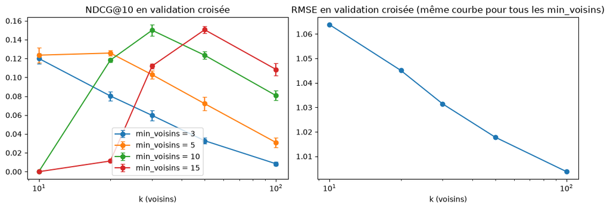

```python
# La même chose en courbes, avec l'écart entre parts en barre d'erreur
fig, axes = plt.subplots(1, 2, figsize=(11, 4))
for m in GRILLE_MIN_VOISINS:
    r = resume.xs(m, level="min_voisins")
    axes[0].errorbar(r.index, r["NDCG@10"], yerr=r["NDCG écart-type"], marker="o", capsize=3, label=f"min_voisins = {m}")
axes[1].plot(r.index, r["RMSE"], marker="o")                        # une seule courbe : la RMSE ne dépend pas de min_voisins
axes[0].set(title="NDCG@10 en validation croisée", xlabel="k (voisins)", xscale="log")
axes[1].set(title="RMSE en validation croisée (même courbe pour tous les min_voisins)", xlabel="k (voisins)", xscale="log")
axes[0].legend(); plt.tight_layout()
```

Le meilleur réglage de la grille est sur son bord (k = 50, min_voisins = 15), et le tableau montre que les deux réglages vont ensemble : le seuil doit valoir environ un tiers du nombre de voisins. On prolonge donc cette crête au-delà de la grille avant de choisir.

```python
# Prolongement de la crête « min_voisins ≈ k / 3 » au-delà de la grille, même validation croisée
CRETE = [(50, 20), (50, 25), (100, 25), (100, 35), (100, 50)]
FICHIER_CRETE = Path("resultats/crete_validation_croisee.csv")

if FICHIER_CRETE.exists():
    crete = pd.read_csv(FICHIER_CRETE)
else:
    parts = parts_validation_croisee(train, N_PARTS, SEUIL_PERTINENT, RANDOM_STATE)
    crete = pd.DataFrame([{"k": k, "min_voisins": m, "part": i,
                           **evaluer_modele(RecoUserBased(k=k, min_voisins=m).fit(train_fit), valid, SEUIL_PERTINENT, TOP_K)}
                          for k, m in CRETE for i, (train_fit, valid) in enumerate(parts)])
    crete.to_csv(FICHIER_CRETE, index=False)

par_reglage = pd.concat([grille, crete]).groupby(["k", "min_voisins"])
resume = par_reglage.mean(numeric_only=True).drop(columns="part")
resume["NDCG écart-type"] = par_reglage["NDCG@10"].std()
resume.loc[[(30, 10), (50, 15)] + CRETE].round(3)
```

| k | min_voisins | RMSE | MAE | précision@10 | rappel@10 | NDCG@10 | popularité médiane | films distincts | NDCG écart-type |
| --- | --- | --- | --- | --- | --- | --- | --- | --- | --- |
| 30 | 10 | 1.031 | 0.794 | 0.106 | 0.137 | 0.150 | 128.8 | 289.2 | 0.006 |
| 50 | 15 | 1.018 | 0.785 | 0.108 | 0.141 | 0.151 | 133.6 | 218.6 | 0.004 |
|  | 20 | 1.018 | 0.785 | 0.101 | 0.119 | 0.147 | 136.4 | 175.6 | 0.005 |
|  | 25 | 1.018 | 0.785 | 0.059 | 0.052 | 0.092 | 138.0 | 120.8 | 0.004 |
| 100 | 25 | 1.004 | 0.777 | 0.101 | 0.128 | 0.137 | 135.8 | 144.4 | 0.006 |
|  | 35 | 1.004 | 0.777 | 0.105 | 0.128 | 0.148 | 142.6 | 125.6 | 0.007 |
|  | 50 | 1.004 | 0.777 | 0.028 | 0.028 | 0.056 | 182.0 | 39.0 | 0.004 |

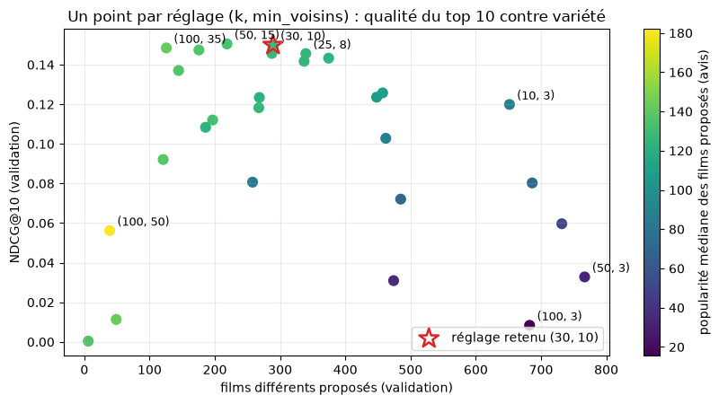

```python
# Le compromis qualité / variété : un point par réglage, l'étoile est le réglage retenu
complement = pd.read_csv("resultats/v2_grille_complement_cv.csv")
resume = pd.concat([grille, crete, complement]).groupby(["k", "min_voisins"]).mean(numeric_only=True).drop(columns="part")
r = resume[resume["films distincts"] > 0]
fig, ax = plt.subplots(figsize=(8.5, 4.6))
sc = ax.scatter(r["films distincts"], r["NDCG@10"], c=r["popularité médiane"], cmap="viridis", s=60)
ax.scatter(*r.loc[[(30, 10)], ["films distincts", "NDCG@10"]].to_numpy().T, facecolor="none", edgecolor="#D62728", s=260, marker="*", linewidths=1.8, label="réglage retenu (30, 10)")
for k, m in [(50, 15), (30, 10), (25, 8), (100, 35), (100, 3), (50, 3), (100, 50), (10, 3)]:
    ax.annotate(f"({k}, {m})", (r.loc[(k, m), "films distincts"], r.loc[(k, m), "NDCG@10"]), fontsize=9, xytext=(6, 4), textcoords="offset points")
plt.colorbar(sc, label="popularité médiane des films proposés (avis)")
ax.set(xlabel="films différents proposés (validation)", ylabel="NDCG@10 (validation)", title="Un point par réglage (k, min_voisins) : qualité du top 10 contre variété")
ax.legend(loc="lower right"); ax.grid(alpha=0.25); plt.tight_layout()
```

```python
# Réglage retenu (v2) : règle à un écart-type, second critère = films distincts (voir la section Compléments)
complement = pd.read_csv("resultats/v2_grille_complement_cv.csv")
par = pd.concat([grille, crete, complement]).groupby(["k", "min_voisins"]).agg(
    **{"NDCG@10": ("NDCG@10", "mean"), "NDCG écart-type": ("NDCG@10", "std"), "RMSE": ("RMSE", "mean"), "films distincts": ("films distincts", "mean")})
best = par["NDCG@10"].idxmax(); marge = par.loc[best, "NDCG écart-type"]
candidats = par[par["NDCG@10"] >= par.loc[best, "NDCG@10"] - marge]
meilleur_k, meilleur_min = candidats["films distincts"].idxmax()
print(f"Meilleur NDCG : {best} ({par.loc[best, 'NDCG@10']:.3f} ± {marge:.3f}) ; indépartageables : {list(candidats.index)}")
print(f"Réglage retenu (le plus varié parmi eux) : k = {meilleur_k}, min_voisins = {meilleur_min}")

reco_initial = RecoUserBased(k=K_VOISINS, min_voisins=MIN_VOISINS).fit(train)
reco_retenu = RecoUserBased(k=meilleur_k, min_voisins=meilleur_min).fit(train)
pd.DataFrame({
    f"initial (k = {K_VOISINS}, min_voisins = {MIN_VOISINS})": evaluer_modele(reco_initial, test, SEUIL_PERTINENT, TOP_K),
    f"retenu (k = {meilleur_k}, min_voisins = {meilleur_min})": evaluer_modele(reco_retenu, test, SEUIL_PERTINENT, TOP_K),
    "(50, 15), argmax du NDCG": evaluer_modele(RecoUserBased(k=50, min_voisins=15).fit(train), test, SEUIL_PERTINENT, TOP_K),
}).round(3)
```

```
Meilleur NDCG : (np.int64(50), np.int64(15)) (0.151 ± 0.004) ; indépartageables : [(30, 10), (50, 15), (50, 20), (100, 35)]
Réglage retenu (le plus varié parmi eux) : k = 30, min_voisins = 10
```

|  | initial (k = 30, min_voisins = 3) | retenu (k = 30, min_voisins = 10) | (50, 15), argmax du NDCG |
| --- | --- | --- | --- |
| RMSE | 1.011 | 1.011 | 0.999 |
| MAE | 0.778 | 0.778 | 0.769 |
| précision@10 | 0.050 | 0.152 | 0.148 |
| rappel@10 | 0.066 | 0.167 | 0.163 |
| NDCG@10 | 0.060 | 0.201 | 0.191 |
| popularité médiane | 54.000 | 151.000 | 159.000 |
| films distincts | 810.000 | 337.000 | 249.000 |

**Réponse.**

**Tableau.** 20 réglages de la grille plus 5 sur la crête, chacun mesuré 5 fois en validation croisée ; le tableau complet est ci-dessus, la lecture en deux tableaux NDCG et RMSE, et les courbes. Le dossier `resultats/` garde les 125 mesures pour ne pas relancer la dizaine de minutes de calcul. Quatre réglages de plus, à petit k, sont mesurés dans la section « Compléments » qui suit.

**Ce que dit la grille.**

- **La RMSE ne dépend que de k** : `min_voisins` ne joue que dans le classement, jamais dans la note prédite. Elle baisse régulièrement avec k, de 1,064 (10 voisins) à 1,004 (100 voisins) : plus de voisins, plus de films couverts, moins de replis sur la moyenne. Résultat stable et monotone, mais toujours au-dessus du repère « biais » de l'exercice 2 (0,908) : le réglage n'y change rien, seul le centrage (question 2) peut le faire.
- **Le top 10 dépend du couple, pas de chaque réglage séparément.** Seuil trop haut pour k, les listes se vident : (10, 10) et (10, 15) valent 0 par construction (un film ne peut pas être vu par 15 voisins sur 10, ce n'est pas un bug), (100, 50) tombe à 0,056. Seuil trop bas, les listes se remplissent de films confidentiels : (100, 3) donne 0,008. Entre les deux, une crête autour de `min_voisins` ≈ k / 3 où le NDCG plafonne à 0,15 : (30, 10) 0,150, (50, 15) 0,151, (100, 35) 0,148. Le rapport fixe la forme, mais le niveau monte avec k : à 10 ou 20 voisins, le meilleur seuil ne dépasse pas 0,143.
- **Stabilité.** Entre les 5 parts, l'écart-type du NDCG vaut 0,002 à 0,008 : deux réglages à moins de 0,01 l'un de l'autre ne sont pas départageables, donc les trois réglages de la crête sont équivalents. En revanche, s'écarter de la crête coûte cher : à k = 50, passer le seuil de 15 à 25 divise le NDCG par 1,6, et à k = 100 le seuil 3 fait tout perdre. Le système est stable le long de la crête, instable en dehors : les deux hyperparamètres doivent être réglés ensemble, pas l'un après l'autre.

**Choix : k = 30, min_voisins = 10, par la règle « à un écart-type ».** Le meilleur NDCG moyen est (50, 15), 0,151 ± 0,004. Mais quatre réglages sont à moins d'un écart-type de ce maximum, donc indépartageables sur le critère principal : (30, 10), (50, 15), (50, 20) et (100, 35). Prendre le maximum reviendrait à choisir sur du bruit. La règle « à un écart-type » (*one standard error rule*, la règle usuelle pour choisir un modèle en validation croisée) départage ces réglages sur un second critère ; la marge est donnée par la validation elle-même, pas choisie à la main. La RMSE désignerait (100, 35) (1,004), mais avec 126 films différents proposés seulement. La variété désigne (30, 10) : 289 films différents contre 219 pour (50, 15) et 126 pour (100, 35), et les films les moins populaires des quatre (129 avis en médiane contre 134 et 143). On prend la variété comme second critère, parce que le cours et l'exercice 5 pointent le biais de popularité comme la faiblesse principale du filtrage collaboratif, et parce que la RMSE n'est ici qu'un contrôle : elle ne dépend que de k et aucun réglage ne la fait passer sous la moyenne de l'utilisateur. k = 30 est au milieu de la fourchette habituelle de la littérature (20 à 50 voisins).

Une limite à connaître : avec 30 voisins et un seuil de 10, 24 utilisateurs sur 671 ont moins de 10 films recommandables et reçoivent une liste plus courte. La précision@10 divise toujours par 10, donc ces utilisateurs sont pénalisés dans la mesure ; ça n'empêche pas le réglage d'être devant sur le test.

**Sur le test, une seule fois.** Le réglage retenu passe la précision@10 de 0,050 à 0,152, le rappel de 0,066 à 0,167 et le NDCG de 0,060 à 0,201, devant le repère populaire (0,109 / 0,099 / 0,146). La RMSE ne bouge pas (1,011), puisque k est le même qu'au départ. Le test confirme aussi que la variété n'a rien coûté : (30, 10) fait même un peu mieux que (50, 15) sur le top 10 (0,201 contre 0,191), pour une RMSE un peu moins bonne (1,011 contre 0,999). Le prix est visible : la popularité médiane des films proposés passe de 54 à 151 avis et le nombre de films distincts de 810 à 337. Il faut le dire honnêtement : exiger qu'un film ait été vu par 10 des 30 voisins, c'est ne garder que les films très vus. Le seuil agit comme un filtre de popularité, et une bonne part du gain vient de là. Le système est devenu bon en se rapprochant du top des ventes, sans s'y réduire (337 films distincts contre 57) ; c'est la question 1 de l'exercice 5.

Les valeurs sur le test sont plus hautes qu'en validation (0,201 contre 0,150) pour deux raisons : le modèle final est entraîné sur tout train, un quart de données de plus ; et le test cache plus de films aimés par utilisateur qu'une part de validation (un cinquième de tous les avis, contre un cinquième de train), or la précision@10 est plafonnée pour un utilisateur qui a moins de 10 films aimés cachés. La comparaison entre réglages, elle, est faite à conditions égales.

### Compléments (v2) : d'autres réglages, et un seuil de similarité

Cette section n'existe que dans la v2. Elle répond à deux questions posées après coup :

1. **Des réglages plus petits sur la crête**, comme (20, 8) ou (25, 8), donnent-ils un top 10 aussi bon que le maximum (50, 15) avec plus de films différents ?
2. **Un seuil de similarité** (on n'est voisin qu'au-dessus d'une similarité cosinus s), en plus des k voisins ou à la place, fait-il mieux ?

Même validation croisée, mêmes 5 parts qu'à la question 1. Les mesures sont gardées dans `resultats/v2_*.csv`.

```python
# Quatre réglages de plus sur la crête, à petit k
COMPLEMENT = [(20, 7), (20, 8), (25, 8), (25, 10)]
FICHIER_COMPLEMENT = Path("resultats/v2_grille_complement_cv.csv")
if FICHIER_COMPLEMENT.exists():
    complement = pd.read_csv(FICHIER_COMPLEMENT)
else:
    parts = parts_validation_croisee(train, N_PARTS, SEUIL_PERTINENT, RANDOM_STATE)
    complement = pd.DataFrame([{"k": k, "min_voisins": m, "part": i,
                                **evaluer_modele(RecoUserBased(k=k, min_voisins=m).fit(train_fit), valid, SEUIL_PERTINENT, TOP_K)}
                               for k, m in COMPLEMENT for i, (train_fit, valid) in enumerate(parts)])
    complement.to_csv(FICHIER_COMPLEMENT, index=False)

par_reglage = pd.concat([grille, crete, complement]).groupby(["k", "min_voisins"])
resume = par_reglage.mean(numeric_only=True).drop(columns="part")
resume["NDCG écart-type"] = par_reglage["NDCG@10"].std()
resume.loc[[(20, 5), (20, 7), (20, 8), (20, 10), (25, 8), (25, 10), (30, 10), (50, 15)],
           ["RMSE", "NDCG@10", "NDCG écart-type", "précision@10", "rappel@10", "popularité médiane", "films distincts"]].round(3)
```

| k | min_voisins | RMSE | NDCG@10 | NDCG écart-type | précision@10 | rappel@10 | popularité médiane | films distincts |
| --- | --- | --- | --- | --- | --- | --- | --- | --- |
| 20 | 5 | 1.045 | 0.126 | 0.003 | 0.090 | 0.127 | 108.6 | 457.2 |
|  | 7 | 1.045 | 0.143 | 0.005 | 0.101 | 0.132 | 124.0 | 374.4 |
|  | 8 | 1.045 | 0.142 | 0.005 | 0.099 | 0.121 | 125.8 | 336.8 |
|  | 10 | 1.045 | 0.118 | 0.002 | 0.082 | 0.081 | 126.6 | 267.4 |
| 25 | 8 | 1.037 | 0.146 | 0.006 | 0.103 | 0.137 | 125.6 | 339.4 |
|  | 10 | 1.037 | 0.146 | 0.006 | 0.102 | 0.124 | 128.2 | 287.4 |
| 30 | 10 | 1.031 | 0.150 | 0.006 | 0.106 | 0.137 | 128.8 | 289.2 |
| 50 | 15 | 1.018 | 0.151 | 0.004 | 0.108 | 0.141 | 133.6 | 218.6 |

```python
# Écart apparié, part par part, entre (50, 15) et les réglages plus variés de la crête
g = pd.concat([grille, crete, complement]).set_index(["k", "min_voisins", "part"]).sort_index()
ref = g.loc[(50, 15)]
lignes = []
for k, m in [(30, 10), (25, 8), (20, 7)]:
    alt = g.loc[(k, m)]
    d = alt["NDCG@10"] - ref["NDCG@10"]
    lignes.append({"réglage": f"({k}, {m})", "écart NDCG moyen": d.mean(), "parts où (50, 15) est meilleur": int((d < 0).sum()),
                   "écart min / max": f"{d.min():+.3f} / {d.max():+.3f}",
                   "films distincts en plus": f"{alt['films distincts'].mean() / ref['films distincts'].mean() - 1:+.0%}"})
pd.DataFrame(lignes).set_index("réglage").round(3)
```

| réglage | écart NDCG moyen | parts où (50, 15) est meilleur | écart min / max | films distincts en plus |
| --- | --- | --- | --- | --- |
| (30, 10) | -0.001 | 4 | -0.005 / +0.006 | +32% |
| (25, 8) | -0.005 | 5 | -0.010 / -0.002 | +55% |
| (20, 7) | -0.007 | 5 | -0.012 / -0.002 | +71% |

**Un choix plus intelligent que l'argmax (v2).** La question 1 prend le réglage au NDCG moyen le plus élevé, sans autre considération. Or deux réglages à moins d'un écart-type entre parts l'un de l'autre ne sont pas départageables, on l'a dit dans le commentaire sur la stabilité. La règle « à un écart-type » (*one standard error rule*, la règle usuelle pour choisir un modèle en validation croisée) en tire la conséquence : parmi les réglages dont le NDCG est à moins d'un écart-type du meilleur, on prend celui qui satisfait un second critère, ici le nombre de films différents proposés. La marge est donnée par la validation elle-même, pas choisie à la main.

```python
# Règle à un écart-type : indépartageables du meilleur, puis le plus varié
resume_tout = pd.concat([grille, crete, complement]).groupby(["k", "min_voisins"]).agg(
    **{"NDCG@10": ("NDCG@10", "mean"), "NDCG écart-type": ("NDCG@10", "std"), "RMSE": ("RMSE", "mean"),
       "films distincts": ("films distincts", "mean"), "popularité médiane": ("popularité médiane", "mean")})
best = resume_tout["NDCG@10"].idxmax()
marge = resume_tout.loc[best, "NDCG écart-type"]
candidats = resume_tout[resume_tout["NDCG@10"] >= resume_tout.loc[best, "NDCG@10"] - marge].sort_values("films distincts", ascending=False)
print(f"Meilleur NDCG : {best}, {resume_tout.loc[best, 'NDCG@10']:.3f} ± {marge:.3f}  ->  indépartageables : {list(candidats.index)}")
print(f"Choix par la règle à un écart-type (le plus varié parmi eux) : {candidats.index[0]}")
candidats.round(3)
```

```
Meilleur NDCG : (np.int64(50), np.int64(15)), 0.151 ± 0.004  ->  indépartageables : [(30, 10), (50, 15), (50, 20), (100, 35)]
Choix par la règle à un écart-type (le plus varié parmi eux) : (np.int64(30), np.int64(10))
```

| k | min_voisins | NDCG@10 | NDCG écart-type | RMSE | films distincts | popularité médiane |
| --- | --- | --- | --- | --- | --- | --- |
| 30 | 10 | 0.150 | 0.006 | 1.031 | 289.2 | 128.8 |
| 50 | 15 | 0.151 | 0.004 | 1.018 | 218.6 | 133.6 |
|  | 20 | 0.147 | 0.005 | 1.018 | 175.6 | 136.4 |
| 100 | 35 | 0.148 | 0.007 | 1.004 | 125.6 | 142.6 |

Avec une marge d'un écart-type (0,004), quatre réglages sont indépartageables de (50, 15), et le plus varié est **(30, 10)** : même NDCG à 0,001 près, 289 films différents au lieu de 219. Avec une marge fixe plus large, la règle glisserait vers (25, 8) à 0,005 ou (20, 7) à 0,010, mais là on paie de la qualité pour de la variété, ce qui n'est plus une règle automatique mais un choix produit. La version 1 du notebook garde l'argmax et (50, 15) ; cette version 2 retient (30, 10) et refait toute la suite avec.

```python
# Un seuil de similarité : en plus des k voisins, ou à la place (k = None)
class RecoSeuil(RecoUserBased):
    """RecoUserBased avec un seuil de similarité min_sim pour être voisin (le code de base a min_sim = 0)."""
    def __init__(self, min_sim=0.0, k=50, **kw):
        super().__init__(k=k if k else 10**6, **kw); self.min_sim = min_sim
    def voisins(self, user):
        v = self.sim.loc[user].nlargest(self.k); return v[v > self.min_sim]

SEUILS = {"référence (50, 15), seuil 0":        dict(k=50,   min_voisins=15, min_sim=0.0),
          "en plus : (50, 15) + seuil 0,10":    dict(k=50,   min_voisins=15, min_sim=0.10),
          "en plus : (50, 15) + seuil 0,15":    dict(k=50,   min_voisins=15, min_sim=0.15),
          "à la place : seuil 0,10, min_v 15":  dict(k=None, min_voisins=15, min_sim=0.10),
          "à la place : seuil 0,15, min_v 15":  dict(k=None, min_voisins=15, min_sim=0.15)}
FICHIER_SEUIL = Path("resultats/v2_seuil_similarite_cv.csv")
if FICHIER_SEUIL.exists():
    seuil = pd.read_csv(FICHIER_SEUIL, index_col=0)
else:
    parts = parts_validation_croisee(train, N_PARTS, SEUIL_PERTINENT, RANDOM_STATE)
    seuil = pd.DataFrame({nom: pd.concat([evaluer_modele(RecoSeuil(**c).fit(t), v, SEUIL_PERTINENT, TOP_K) for t, v in parts], axis=1).mean(axis=1)
                          for nom, c in SEUILS.items()}).T
    seuil.to_csv(FICHIER_SEUIL)
seuil[["RMSE", "NDCG@10", "précision@10", "rappel@10", "popularité médiane", "films distincts"]].round(3)
```

|  | RMSE | NDCG@10 | précision@10 | rappel@10 | popularité médiane | films distincts |
| --- | --- | --- | --- | --- | --- | --- |
| reference (50, 15), seuil 0 | 1.018 | 0.151 | 0.108 | 0.141 | 133.6 | 218.6 |
| en plus : (50, 15) + seuil 0,10 | 1.016 | 0.145 | 0.105 | 0.133 | 130.8 | 210.8 |
| en plus : (50, 15) + seuil 0,15 | 1.014 | 0.123 | 0.091 | 0.106 | 128.8 | 202.6 |
| a la place : seuil 0,10, min_v 15 | 0.993 | 0.070 | 0.049 | 0.063 | 89.2 | 197.0 |
| a la place : seuil 0,15, min_v 15 | 1.003 | 0.091 | 0.066 | 0.076 | 125.6 | 198.2 |

```python
# Pourquoi le seuil seul échoue : les similarités sont très différentes d'un utilisateur à l'autre
S = reco_retenu.sim.to_numpy()
tri = -np.sort(-S, axis=1)
print("similarité du 1er / 15e / 50e voisin (min / médiane / max selon l'utilisateur) :",
      " ; ".join(f"n°{p+1} : {tri[:, p].min():.2f} / {np.median(tri[:, p]):.2f} / {tri[:, p].max():.2f}" for p in (0, 14, 49)))
for s in (0.05, 0.10, 0.15, 0.20):
    n = (S > s).sum(axis=1)
    print(f"seuil {s:.2f} : de {n.min()} à {n.max()} voisins selon l'utilisateur (médiane {int(np.median(n))}), "
          f"{(n < meilleur_min).sum()} utilisateurs sous les {meilleur_min} voisins requis")
```

```
similarité du 1er / 15e / 50e voisin (min / médiane / max selon l'utilisateur) : n°1 : 0.08 / 0.32 / 0.74 ; n°15 : 0.05 / 0.23 / 0.55 ; n°50 : 0.03 / 0.18 / 0.40
seuil 0.05 : de 10 à 631 voisins selon l'utilisateur (médiane 407), 0 utilisateurs sous les 10 voisins requis
seuil 0.10 : de 0 à 522 voisins selon l'utilisateur (médiane 206), 34 utilisateurs sous les 10 voisins requis
seuil 0.15 : de 0 à 388 voisins selon l'utilisateur (médiane 87), 109 utilisateurs sous les 10 voisins requis
seuil 0.20 : de 0 à 247 voisins selon l'utilisateur (médiane 30), 222 utilisateurs sous les 10 voisins requis
```

**Réponse (v2).**

**D'autres réglages.** La crête `min_voisins` ≈ k / 3 tient aussi à petit k : à k = 20, le meilleur seuil est 7 (0,143), pas 5 (0,126) ni 10 (0,118). Le niveau monte avec k mais de moins en moins, 0,143 à k = 20, 0,146 à 25, 0,150 à 30, 0,151 à 50, et la variété suit la direction inverse : (25, 8) propose 339 films différents contre 219 pour (50, 15), soit 55 % de plus. L'écart apparié part par part départage : (30, 10) est indépartageable de (50, 15), écarts de −0,005 à +0,006 ; (25, 8) et (20, 7) sont moins bons sur 5 parts sur 5, de peu. Le plateau commence donc vers k = 25, et il est plus large que la grille de la question 1 ne le montrait.

**Un seuil de similarité.** À la place des k voisins, le NDCG est divisé par deux (0,070 à s = 0,10, 0,091 à s = 0,15), pour une RMSE un peu meilleure. La cause : le 50e voisin d'un utilisateur vaut 0,03 chez certains et 0,40 chez d'autres. À s = 0,10, un utilisateur a 0 voisin et un autre plus de 500, et 34 utilisateurs n'atteignent même pas les 10 voisins de notre réglage. Pour ceux qui ont des centaines de voisins, un seuil de 10 ou 15 devient dérisoire et les listes se remplissent de films confidentiels, comme à (100, 3) ; un seuil fixe casse le lien entre k et `min_voisins` que la grille avait montré. En plus des k voisins, le seuil est au mieux neutre : −0,006 à s = 0,10, −0,028 à s = 0,15. L'intuition est juste, un voisin à 0,03 compte autant qu'un voisin à 0,50 dans le compte de `min_voisins`, mais la moyenne pondérée par la similarité compense déjà, et couper les voisins faibles retire surtout des voisins à ceux qui en ont peu. On garde les k voisins.

```python
# Vérification sur le test, une seule fois : le choix reste fait en validation
VERIF = [(50, 15), (30, 10), (25, 8), (20, 7)]
verif_test = pd.DataFrame({f"({k}, {m})": evaluer_modele(RecoUserBased(k=k, min_voisins=m).fit(train), test, SEUIL_PERTINENT, TOP_K) for k, m in VERIF})
verif_test["films les plus notés"] = evaluer_populaire(train, test, SEUIL_PERTINENT, TOP_K)
verif_test.round(3)
```

|  | (50, 15) | (30, 10) | (25, 8) | (20, 7) | films les plus notés |
| --- | --- | --- | --- | --- | --- |
| RMSE | 0.999 | 1.011 | 1.017 | 1.025 | NaN |
| MAE | 0.769 | 0.778 | 0.781 | 0.786 | NaN |
| précision@10 | 0.148 | 0.152 | 0.145 | 0.148 | 0.109 |
| rappel@10 | 0.163 | 0.167 | 0.162 | 0.166 | 0.099 |
| NDCG@10 | 0.191 | 0.201 | 0.190 | 0.195 | 0.146 |
| popularité médiane | 159.000 | 151.000 | 138.000 | 133.000 | 200.000 |
| films distincts | 249.000 | 337.000 | 397.000 | 427.000 | 57.000 |

```python
# La variété en plus est-elle utile ? Les bons films trouvés (aimés cachés) sont-ils aussi plus variés ?
from evaluation import pertinents_test
pert = pertinents_test(test, SEUIL_PERTINENT)
n_avis_train = train.groupby("movieId").size()
lignes = []
for k, m in VERIF:
    listes_km = {u: list(RecoUserBased(k=k, min_voisins=m).fit(train).recommander(u, TOP_K).index) for u in test["userId"].unique()}
    hits = [f for u, l in listes_km.items() for f in l if f in pert.get(u, set())]
    lignes.append({"réglage": f"({k}, {m})", "films distincts proposés": len({f for l in listes_km.values() for f in l}),
                   "bons films trouvés": len(hits), "bons films distincts": len(set(hits)),
                   "popularité médiane des bons films": np.median([n_avis_train[f] for f in hits])})
pd.DataFrame(lignes).set_index("réglage")
```

| réglage | films distincts proposés | bons films trouvés | bons films distincts | popularité médiane des bons films |
| --- | --- | --- | --- | --- |
| (50, 15) | 249 | 995 | 167 | 160.0 |
| (30, 10) | 337 | 1018 | 196 | 154.0 |
| (25, 8) | 397 | 972 | 206 | 150.0 |
| (20, 7) | 427 | 992 | 221 | 150.0 |

**Sur le test.** (30, 10) obtient un NDCG de 0,201 contre 0,191 pour (50, 15), avec 337 films différents contre 249 et des films un peu moins populaires (151 avis en médiane contre 159) ; la RMSE est un peu moins bonne (1,011 contre 0,999). Les bons films trouvés sont eux aussi plus variés (196 films distincts contre 167, pour autant de bons films) : la variété en plus n'est pas du remplissage. Le choix reste fait en validation, par la règle à un écart-type ; le test ne sert qu'à vérifier, une seule fois, qu'il ne coûte rien en qualité. (25, 8) et (20, 7) confirment le sens de la crête (plus de films, moins populaires) mais restent derrière en validation sur 5 parts sur 5 : on s'arrête à (30, 10).

### 2) Une amélioration : le centrage des notes

> 2. Implémenter l'une des modifications suivantes au choix et les comparer avec votre système : le filtrage des utilisateurs trop peu actifs dans la base d'entraînement avant d'entraîner, le centrage des notes par utilisateur avant le calcul de similarité, le passage à un système de filtrage collaboratif item-based.

On choisit le **centrage**, parce qu'il vise le point faible mesuré à l'exercice 2 : le système ignore le niveau de chaque utilisateur, et sa RMSE est moins bonne que la simple moyenne de l'utilisateur. Les deux autres options : le filtrage des inactifs est prévu dans la classe (`min_avis`) mais chaque utilisateur a au moins 16 avis en train, peu d'effet à attendre ; l'item-based est un autre système, gardé pour un bonus.

*Centrage* : avant de calculer les similarités, on retire à chaque utilisateur sa note moyenne. Un 4 chez quelqu'un qui met 4,5 partout devient −0,5 ; un 4 chez quelqu'un qui met 2,5 partout devient +1,5. Deux utilisateurs sont alors similaires s'ils aiment et détestent les mêmes films, pas s'ils notent au même niveau. Pour prédire, on moyenne ces écarts chez les voisins puis on rajoute la moyenne de l'utilisateur : il retrouve son niveau. Sur notes centrées, une similarité peut devenir négative (goûts opposés) ; c'est là que le `clip` à 0 de la classe entre en jeu.

Dans la classe, c'est l'option `centrer=True` : `X` contient les notes moins la moyenne de la ligne, et `score` rajoute la moyenne. On compare brut et centré sur le réglage retenu, d'abord en validation croisée (mêmes 5 parts qu'à la question 1), puis une seule fois sur le test. Le seuil `min_voisins` ayant été réglé pour le système brut, on vérifie aussi deux autres seuils pour le centré.

```python
# Brut et centré, même réglage (k = 30, min_voisins = 10) et mêmes 5 parts qu'à la question 1
parts = parts_validation_croisee(train, N_PARTS, SEUIL_PERTINENT, RANDOM_STATE)

def moyenne_validation(Modele, **reglages):
    mesures = [evaluer_modele(Modele(**reglages).fit(t), v, SEUIL_PERTINENT, TOP_K) for t, v in parts]
    return pd.concat(mesures, axis=1).mean(axis=1)

validation = pd.DataFrame({
    "brut": moyenne_validation(RecoUserBased, k=meilleur_k, min_voisins=meilleur_min),
    "centré": moyenne_validation(RecoUserBased, k=meilleur_k, min_voisins=meilleur_min, centrer=True),
    "centré, seuil 7": moyenne_validation(RecoUserBased, k=meilleur_k, min_voisins=7, centrer=True),   # le seuil a été réglé pour le brut
    "centré, seuil 13": moyenne_validation(RecoUserBased, k=meilleur_k, min_voisins=13, centrer=True),
    "films les plus notés": pd.concat([evaluer_populaire(t, v, SEUIL_PERTINENT, TOP_K) for t, v in parts], axis=1).mean(axis=1),   # repère sans modèle
})
validation.round(3)
```

|  | brut | centré | centré, seuil 7 | centré, seuil 13 | films les plus notés |
| --- | --- | --- | --- | --- | --- |
| MAE | 0.794 | 0.739 | 0.739 | 0.739 | NaN |
| NDCG@10 | 0.150 | 0.120 | 0.126 | 0.070 | 0.107 |
| RMSE | 1.031 | 0.971 | 0.971 | 0.971 | NaN |
| films distincts | 289.200 | 209.400 | 302.600 | 127.800 | 37.800 |
| popularité médiane | 128.800 | 138.400 | 133.600 | 148.600 | 159.800 |
| précision@10 | 0.106 | 0.078 | 0.093 | 0.037 | 0.076 |
| rappel@10 | 0.137 | 0.096 | 0.116 | 0.045 | 0.089 |

```python
# Une seule fois sur le test : le système retenu (brut) et le même, centré
reco_centre = RecoUserBased(k=meilleur_k, min_voisins=meilleur_min, centrer=True).fit(train)
print(f"Paires d'utilisateurs de similarité > 0 : brut {(reco_retenu.sim > 0).mean().mean():.0%}, centré {(reco_centre.sim > 0).mean().mean():.0%}")
pd.DataFrame({"brut": evaluer_modele(reco_retenu, test, SEUIL_PERTINENT, TOP_K),
              "centré": evaluer_modele(reco_centre, test, SEUIL_PERTINENT, TOP_K)}).round(3)
```

```
Paires d'utilisateurs de similarité > 0 : brut 82%, centré 54%
```

|  | brut | centré |
| --- | --- | --- |
| RMSE | 1.011 | 0.947 |
| MAE | 0.778 | 0.721 |
| précision@10 | 0.152 | 0.144 |
| rappel@10 | 0.167 | 0.144 |
| NDCG@10 | 0.201 | 0.191 |
| popularité médiane | 151.000 | 166.000 |
| films distincts | 337.000 | 269.000 |

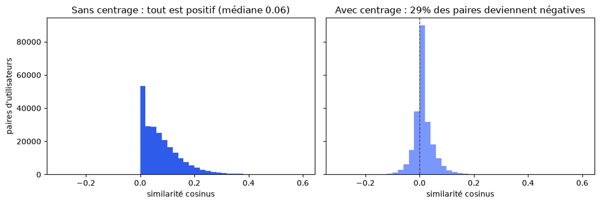

```python
# Ce que le centrage change dans les similarités : toutes les paires d'utilisateurs, avant le clip à 0
def similarites(X):
    X0 = X.fillna(0.0).to_numpy()
    norme = np.linalg.norm(X0, axis=1, keepdims=True); norme[norme == 0] = 1.0
    sim = (X0 @ X0.T) / (norme @ norme.T)
    return sim[np.triu_indices_from(sim, k=1)]                      # chaque paire une fois

brut, centre = similarites(reco_retenu.X), similarites(reco_centre.X)
fig, axes = plt.subplots(1, 2, figsize=(11, 3.8), sharey=True)
bins = np.linspace(-0.3, 0.6, 46)
axes[0].hist(brut, bins=bins, color="#2F5BEA"); axes[0].set(title=f"Sans centrage : tout est positif (médiane {np.median(brut):.2f})", xlabel="similarité cosinus", ylabel="paires d'utilisateurs")
axes[1].hist(centre, bins=bins, color="#7A97FF"); axes[1].axvline(0, color="#444", ls="--", lw=1)
axes[1].set(title=f"Avec centrage : {(centre < 0).mean():.0%} des paires deviennent négatives", xlabel="similarité cosinus")
plt.tight_layout()
```

**Réponse.**

| Réglage (30, 10) | RMSE valid. | NDCG@10 valid. | RMSE test | NDCG@10 test | Films distincts (test) |
| --- | --- | --- | --- | --- | --- |
| Brut (système retenu) | 1,031 | **0,150** | 1,011 | **0,201** | 337 |
| Centré | **0,971** | 0,120 | **0,947** | 0,191 | 269 |

**Ce que le centrage gagne : la prédiction de notes.** RMSE de 1,031 à 0,971 en validation, de 1,011 à 0,947 sur le test, MAE de 0,778 à 0,721. Le système centré bat enfin la moyenne de l'utilisateur (0,954) ; il reste derrière le repère biais (0,908), qui connaît aussi le niveau de chaque film. C'est le gain attendu : la cause n° 1 de l'exercice 2, le niveau de l'utilisateur ignoré, est corrigée. Le gain est identique pour les trois seuils testés, puisque le seuil ne joue pas dans la note prédite.

**Ce qu'il perd : le classement.** En validation, le NDCG passe de 0,150 à 0,120, un écart bien supérieur au bruit entre parts (0,002 à 0,008), et changer le seuil ne le rattrape pas (0,126 avec 7, 0,070 avec 13). Sur le test, une seule mesure, le centré est aussi derrière : 0,191 contre 0,201, précision 0,144 contre 0,152, rappel 0,144 contre 0,167. Sur le biais de popularité, il n'aide pas non plus : films proposés plus populaires (166 avis en médiane contre 151) et moins variés (269 films distincts contre 337). Ce qui change sous le capot : avec les notes centrées, 54 % des paires d'utilisateurs ont une similarité positive contre 82 % en brut, parce que les goûts opposés sont maintenant à 0. Les voisins sont donc différents, choisis sur les goûts et non plus sur le niveau et le volume de notes ; avec 30 voisins seulement, en perdre une partie se paie sur la couverture.

**Décision.** Le critère posé à la question 1 est le NDCG@10 en validation, et il donne le système brut, en validation comme sur le test. On le garde pour recommander, et c'est lui que l'exercice 5 analyse. Le centré est le meilleur des deux pour prédire une note ; si l'application était d'afficher une note prédite plutôt qu'un top 10, ce serait lui. La leçon : une amélioration peut aider une métrique et pas l'autre, il faut savoir laquelle compte pour l'usage.

### Bonus : un système item-based

> (Troisième option de la question 2) le passage à un système de filtrage collaboratif item-based.

*Item-based* : même idée que le user-based, mais on compare les **films** entre eux au lieu des utilisateurs. Deux films sont similaires si les mêmes personnes les ont notés de la même façon : similarité cosinus entre les colonnes de la matrice des avis, avec le même 0 dans les cases vides (cours, pages 21 et 22). Pour recommander, l'algorithme du cours (page 24) : on prend les n films que l'utilisateur a préférés, pour chacun ses k films les plus proches qu'il n'a pas vus, et on prédit la note de chaque candidat par la moyenne des notes de l'utilisateur sur ses favoris, pondérée par la similarité ; on classe par note prédite. Pour prédire la note d'un film donné (RMSE), on prend les k films notés par l'utilisateur les plus proches de celui-là, même moyenne pondérée. La différence entre n et k : n est le nombre de points de départ (les goûts de l'utilisateur), k le nombre de films ramenés par chaque point.

Deux différences avec le user-based. La prédiction part des notes de l'utilisateur lui-même : son niveau est conservé sans centrage. Et la matrice de similarité grandit avec le nombre de films, pas d'utilisateurs : on ne garde que les films ayant au moins `min_avis` avis en train (sinon leur similarité repose sur une poignée de noteurs), soit 3 081 films à 5 avis contre 671 utilisateurs. Trois réglages : `k`, `n_favoris` et `min_avis`.

*Règle de classement.* Le cours classe les candidats par note prédite. Pour l'item-based, cette note est une moyenne, et ça pose problème. Exemple : un utilisateur a pour favoris *Le Parrain* (5), *Pulp Fiction* (5) et *Alien* (4). Le film A ressemble aux trois (similarités 0,4, 0,3 et 0,3), le film B ne ressemble qu'au *Parrain* (0,1). Par note prédite, A obtient (0,4×5 + 0,3×5 + 0,3×4) / (0,4 + 0,3 + 0,3) = 4,7 et B obtient 0,1×5 / 0,1 = 5,0 : B passe devant alors qu'il n'est relié qu'à un seul favori, et faiblement. C'est le même piège qu'avec les films vus par un seul voisin. La règle usuelle du top N item-based ne divise pas : le score est la somme des similarités × notes des favoris, A obtient 4,7 et B 0,5, être relié à plusieurs favoris compte. Le score ne sert qu'à ordonner, la note affichée reste la moyenne pondérée. La classe a les deux (`classement="note"` ou `"somme"`) ; on les compare en validation croisée avec quelques réglages, puis le meilleur une seule fois sur le test contre les deux systèmes user-based.

```python
# La classe est dans modeles.py ; on affiche sa source pour la lecture
print(inspect.getsource(RecoItemBased))
```

```
class RecoItemBased:
    """Filtrage collaboratif item-based : similarité cosinus entre films, moyenne pondérée des notes de l'utilisateur.

    Note prédite d'un film = moyenne des notes de l'utilisateur sur les k films notés les plus proches, pondérée par
    la similarité. Recommandation = algorithme du cours : ses n_favoris films préférés, les k plus proches non vus de
    chacun, puis classement. Exercice 4, bonus.

    k          : films voisins retenus (au plus) : par film à prédire, ou par favori pour recommander.
    n_favoris  : films préférés de l'utilisateur d'où partent les recommandations.
    min_avis   : un film doit avoir au moins min_avis avis en train pour avoir une similarité (sinon trop bruitée).
    classement : "note", par note prédite (cours) ; "somme", par somme des similarités x notes des favoris
                 (règle usuelle du top N item-based : un film relié à dix favoris passe devant un film relié à un seul).
    """

    def __init__(self, k=10, n_favoris=10, min_avis=5, classement="note"):
        self.k = k
        self.n_favoris = n_favoris
        self.min_avis = min_avis
        self.classement = classement

    def fit(self, train):
        self.R = train.pivot(index="userId", columns="movieId", values="rating")
        self.moyenne = self.R.mean(axis=1)
        self.moyenne_globale = train["rating"].mean()

        # Films assez notés ; 0 dans les cases vides, une ligne par film
        n_avis = self.R.notna().sum()
        self.films = n_avis[n_avis >= self.min_avis].index
        X0 = self.R[self.films].fillna(0.0).to_numpy().T

        # Similarité cosinus entre tous les films
        norme = np.linalg.norm(X0, axis=1, keepdims=True)
        sim = (X0 @ X0.T) / (norme @ norme.T)
        np.fill_diagonal(sim, 0.0)
        self.sim = pd.DataFrame(sim, index=self.films, columns=self.films)
        return self

    def niveau(self, user):
        """Note moyenne de l'utilisateur (moyenne globale s'il est inconnu du modèle)."""
        return self.moyenne.get(user, self.moyenne_globale)
```

[output cut: 24 more lines]

```
        if user not in self.R.index:
            return pd.DataFrame(columns=["note prédite", "voisins"])
        notes = self.R.loc[user, self.films].dropna()
        favoris = notes.nlargest(self.n_favoris)                            # ses films préférés
        if favoris.empty:
            return pd.DataFrame(columns=["note prédite", "voisins"])
        S = self.sim[favoris.index].copy()                                  # similarité de chaque film avec les favoris
        S.loc[notes.index] = 0.0                                            # films déjà vus : pas candidats
        kieme = -np.partition(-S.to_numpy(), self.k - 1, axis=0)[self.k - 1]   # k-ième plus proche de chaque favori
        S = S.where(S >= kieme, 0.0)                                        # ne garder que les k plus proches par favori
        somme = pd.Series(S.to_numpy() @ favoris.to_numpy(), index=S.index)  # somme des similarités x notes des favoris
        note = somme / S.sum(axis=1)                                        # moyenne pondérée = note prédite
        score = somme if self.classement == "somme" else note
        top = score[S.sum(axis=1) > 0].nlargest(n)
        return pd.DataFrame({"note prédite": note[top.index].clip(0.5, 5.0), "voisins": (S.loc[top.index] > 0).sum(axis=1)})
```

```python
# Item-based en validation croisée (mêmes 5 parts) : les deux règles de classement, quelques réglages
REGLAGES_ITEM = {
    "note, min_avis 5, n 10, k 10":    dict(classement="note",  min_avis=5,  n_favoris=10, k=10),
    "note, min_avis 50, n 10, k 10":   dict(classement="note",  min_avis=50, n_favoris=10, k=10),
    "somme, min_avis 5, n 20, k 20":   dict(classement="somme", min_avis=5,  n_favoris=20, k=20),
    "somme, min_avis 5, n 50, k 30":   dict(classement="somme", min_avis=5,  n_favoris=50, k=30),
    "somme, min_avis 20, n 50, k 30":  dict(classement="somme", min_avis=20, n_favoris=50, k=30),
}
validation_item = pd.DataFrame({nom: moyenne_validation(RecoItemBased, **r) for nom, r in REGLAGES_ITEM.items()})
validation_item.round(3).T
```

|  | RMSE | MAE | précision@10 | rappel@10 | NDCG@10 | popularité médiane | films distincts |
| --- | --- | --- | --- | --- | --- | --- | --- |
| note, min_avis 5, n 10, k 10 | 0.908 | 0.692 | 0.045 | 0.051 | 0.060 | 70.2 | 1162.0 |
| note, min_avis 50, n 10, k 10 | 0.939 | 0.721 | 0.052 | 0.055 | 0.066 | 91.6 | 228.2 |
| somme, min_avis 5, n 20, k 20 | 0.905 | 0.690 | 0.102 | 0.130 | 0.144 | 103.0 | 792.2 |
| somme, min_avis 5, n 50, k 30 | 0.907 | 0.692 | 0.106 | 0.134 | 0.148 | 104.6 | 689.6 |
| somme, min_avis 20, n 50, k 30 | 0.928 | 0.709 | 0.109 | 0.135 | 0.153 | 104.8 | 402.2 |

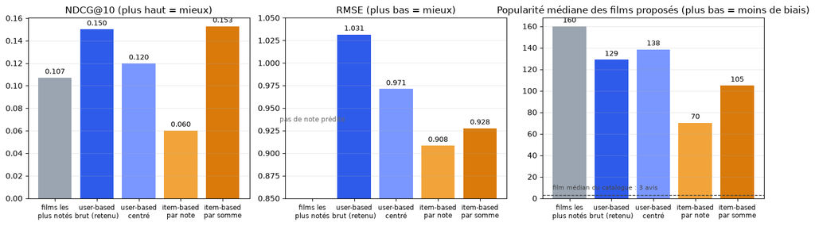

```python
# Le repère, le système retenu et ses variantes, mesurés de la même façon en validation : NDCG, RMSE, popularité
colonnes = {"films les\nplus notés": validation["films les plus notés"], "user-based\nbrut (retenu)": validation["brut"],
            "user-based\ncentré": validation["centré"], "item-based\npar note": validation_item["note, min_avis 5, n 10, k 10"],
            "item-based\npar somme": validation_item[validation_item.loc["NDCG@10"].idxmax()]}   # le meilleur réglage item-based
comp = pd.DataFrame(colonnes)
fig, axes = plt.subplots(1, 3, figsize=(14, 4.2))
for ax, ligne, titre in zip(axes, ["NDCG@10", "RMSE", "popularité médiane"],
                            ["NDCG@10 (plus haut = mieux)", "RMSE (plus bas = mieux)", "Popularité médiane des films proposés (plus bas = moins de biais)"]):
    vals = comp.loc[ligne]
    barres = ax.bar(vals.index, vals.fillna(0), color=["#9aa5b1", "#2F5BEA", "#7A97FF", "#F2A43A", "#D97A0B"])
    ax.bar_label(barres, labels=[f"{v:.3f}" if ligne != "popularité médiane" else f"{v:.0f}" for v in vals.fillna(0)], padding=3, fontsize=9)
    ax.set(title=titre); ax.tick_params(axis="x", labelsize=8.5); ax.grid(axis="y", alpha=0.25)
axes[1].set_ylim(0.85, 1.05); axes[1].annotate("pas de note prédite", (0, 0.935), ha="center", fontsize=8.5, color="#666")
axes[2].axhline(3, color="#444", ls="--", lw=1); axes[2].annotate("film médian du catalogue : 3 avis", (-0.4, 8), fontsize=8, color="#444")
plt.tight_layout()
```

```python
# Une seule fois sur le test : le réglage item-based au meilleur NDCG en validation, contre les deux user-based
nom_item = validation_item.loc["NDCG@10"].idxmax()
reco_item = RecoItemBased(**REGLAGES_ITEM[nom_item]).fit(train)
print(f"Item-based retenu : {nom_item} ({len(reco_item.films)} films avec une similarité)")
pd.DataFrame({"user-based brut": evaluer_modele(reco_retenu, test, SEUIL_PERTINENT, TOP_K),
              "user-based centré": evaluer_modele(reco_centre, test, SEUIL_PERTINENT, TOP_K),
              "item-based": evaluer_modele(reco_item, test, SEUIL_PERTINENT, TOP_K)}).round(3)
```

```
Item-based retenu : somme, min_avis 20, n 50, k 30 (1043 films avec une similarité)
```

|  | user-based brut | user-based centré | item-based |
| --- | --- | --- | --- |
| RMSE | 1.011 | 0.947 | 0.915 |
| MAE | 0.778 | 0.721 | 0.698 |
| précision@10 | 0.152 | 0.144 | 0.181 |
| rappel@10 | 0.167 | 0.144 | 0.179 |
| NDCG@10 | 0.201 | 0.191 | 0.249 |
| popularité médiane | 151.000 | 166.000 | 128.000 |
| films distincts | 337.000 | 269.000 | 410.000 |

**Réponse (bonus).**

|  | RMSE valid. | NDCG@10 valid. | Films distincts valid. | RMSE test | NDCG@10 test |
| --- | --- | --- | --- | --- | --- |
| User-based brut (30, 10) | 1,031 | 0,150 | 289 | 1,011 | 0,201 |
| User-based centré (30, 10) | 0,971 | 0,120 | 209 | 0,947 | 0,191 |
| Item-based, classement par note (cours), min_avis 5 | **0,908** | 0,060 | 1 162 |  |  |
| Item-based, classement par somme, min_avis 20, n 50, k 30 (retenu) | 0,928 | **0,153** | 402 | **0,915** | **0,249** |

**Le meilleur pour prédire une note.** Avec les films à 5 avis ou plus, l'item-based obtient la meilleure RMSE de tout le TP en validation, 0,908, devant le centré (0,971) et le brut (1,031). Il part des notes de l'utilisateur lui-même, son niveau est donc conservé sans rien faire, et les similarités entre films sont plus fiables que celles entre utilisateurs : un film populaire est noté par des centaines de personnes, un utilisateur n'a que quelques dizaines de films en commun avec un autre. Monter `min_avis` dégrade un peu la RMSE, parce que les films écartés n'ont plus de prédiction et se replient sur la moyenne de l'utilisateur.

**Le classement dépend entièrement de la règle.** Avec la règle du cours, classer par note prédite, le NDCG plafonne à 0,066 : un candidat relié à un seul favori noté 5 par une similarité faible obtient 5 et passe en tête, et ce sont souvent des films peu vus (popularité médiane 70 avis). Avec la somme des similarités × notes, un film relié à dix favoris passe devant un film relié à un seul : le NDCG monte à 0,144 – 0,153, au niveau du user-based (0,150, écart entre parts 0,004 à 0,007), sans aucun seuil de voisins. Et à égalité de NDCG, l'item-based propose des films moins populaires (105 avis en médiane contre 129) et de 1,4 à près de 3 fois plus de films distincts. Le réglage retenu, au meilleur NDCG en validation : somme, `min_avis` 20, n = 50 favoris, k = 30.

**Sur le test, une seule fois.** L'item-based retenu passe devant : NDCG 0,249 contre 0,201, précision 0,181 contre 0,152, RMSE 0,915 contre 1,011, avec des films moins populaires (128 avis contre 151) et 410 films distincts contre 337. L'écart est plus grand qu'en validation parce que le modèle final a un quart de données de plus, donc 1 043 films à 20 avis ou plus au lieu d'environ 800 : l'item-based profite plus de la taille du catalogue que le user-based.

**Bilan.** Le user-based reste le système du TP, construit et réglé aux exercices 2 à 4, et c'est lui que l'exercice 5 analyse. Mais le bonus montre qu'à ce stade, le meilleur système disponible est l'item-based avec classement par somme, sur toutes les métriques à la fois ; l'exercice 5 le garde en point de comparaison et en amélioration.

## Exercice 5 – Analyse critique

> Justifier chaque réponse qui s'y prête à l'aide d'arguments numériques.
> 1. Votre système favorise-t-il les films populaires ? Estimez-vous que c'est une bonne chose ?
> 2. Les recommandations faites pour un utilisateur sont-elles diverses ?
> 3. Les recommandations faites au global sont-elles diverses ?
> 4. Les recommandations sont-elles réellement personnalisées ?
> 5. Comment amélioreriez-vous votre système en production ?

Le système analysé est celui du TP : le user-based retenu à l'exercice 4 (k = 30, min_voisins = 10). On met à côté l'item-based du bonus et le repère « populaire », pour situer chaque chiffre. Les mesures portent sur les top 10 des 671 utilisateurs, calculés une fois ci-dessous.

```python
# Les top 10 de chaque système pour tous les utilisateurs, calculés une fois
utilisateurs = sorted(test["userId"].unique())
listes_ub = {u: list(reco_retenu.recommander(u, TOP_K).index) for u in utilisateurs}
listes_ib = {u: list(reco_item.recommander(u, TOP_K).index) for u in utilisateurs}
systemes = {"user-based retenu": listes_ub, "item-based (bonus)": listes_ib, "populaire": listes_pop}
print({nom: f"{sum(len(l) for l in listes.values())} films proposés" for nom, listes in systemes.items()})
```

```
{'user-based retenu': '6642 films proposés', 'item-based (bonus)': '6710 films proposés', 'populaire': '6710 films proposés'}
```

### 1) Favorise-t-il les films populaires ?

*Popularité* d'un film : son nombre d'avis en train. *Biais de popularité* (cours, page 26) : un système qui ne propose que des films déjà très vus, au détriment de films peu connus mais pertinents. On compare la popularité des films proposés à celle du catalogue, et on regarde quelle part des recommandations tombe dans le top 50 des films les plus notés.

```
Catalogue : 8384 films, popularité médiane 3 avis, 88% des films ont moins de 20 avis
```

|  | user-based retenu | item-based (bonus) | populaire |
| --- | --- | --- | --- |
| popularité médiane (avis en train) | 151.000 | 128.000 | 200.000 |
| part des recommandations dans le top 50 | 0.576 | 0.518 | 0.999 |
| part de films à moins de 20 avis | 0.003 | 0.000 | 0.000 |

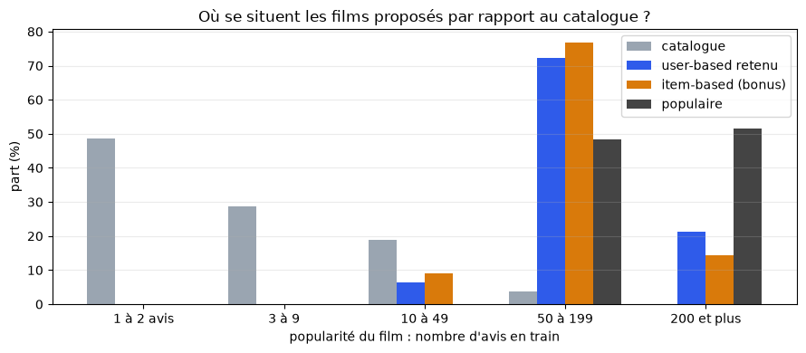

```python
# Popularité des films proposés, comparée au catalogue et au top des ventes
top50 = set(populaires[:50])
def popularite(listes):
    films = [f for l in listes.values() for f in l]
    return pd.Series({"popularité médiane (avis en train)": np.median([n_avis.get(f, 0) for f in films]),
                      "part des recommandations dans le top 50": np.mean([f in top50 for f in films]),
                      "part de films à moins de 20 avis": np.mean([n_avis.get(f, 0) < 20 for f in films])})
print(f"Catalogue : {len(n_avis)} films, popularité médiane {n_avis.median():.0f} avis, "
      f"{(n_avis < 20).mean():.0%} des films ont moins de 20 avis")
display(pd.DataFrame({nom: popularite(l) for nom, l in systemes.items()}).round(3))

# Répartition par tranche de popularité : le catalogue contre les films proposés
tranches, noms = [0, 2, 9, 49, 199, 10**9], ["1 à 2 avis", "3 à 9", "10 à 49", "50 à 199", "200 et plus"]
def par_tranche(valeurs):
    return pd.cut(pd.Series(valeurs), tranches, labels=noms).value_counts(normalize=True).reindex(noms).fillna(0) * 100
repartition = pd.DataFrame({"catalogue": par_tranche(n_avis.to_numpy()),
                            **{nom: par_tranche([n_avis.get(f, 0) for l in listes.values() for f in l]) for nom, listes in systemes.items()}})
ax = repartition.plot.bar(figsize=(9, 4), color=["#9aa5b1", "#2F5BEA", "#D97A0B", "#444"], rot=0, width=0.8)
ax.set(ylabel="part (%)", xlabel="popularité du film : nombre d'avis en train", title="Où se situent les films proposés par rapport au catalogue ?")
ax.grid(axis="y", alpha=0.25); plt.tight_layout()
```

**Réponse.** **Oui, nettement.** Le film médian du catalogue a 3 avis et 88 % des films en ont moins de 20 ; le film médian proposé par notre système en a 151, le film le moins vu qu'il propose en a 12, et 0,3 % des recommandations vont à des films de moins de 20 avis. 58 % des recommandations tombent dans le top 50 des films les plus notés (52 % pour l'item-based, 100 % pour le top des ventes). La figure le montre : la moitié du catalogue a 1 ou 2 avis, et le système ne propose rien en dessous de 10 avis ; 94 % de ses recommandations vont à des films de 50 avis et plus, une tranche qui ne fait que 4 % du catalogue.

La cause est connue depuis l'exercice 4 : exiger qu'un film ait été vu par 10 des 30 voisins ne laisse passer que des films très vus. C'est le *biais de popularité* du cours (page 26) : les films peu populaires ne sont jamais recommandés, même s'ils sont pertinents. Et c'est nous qui l'avons renforcé en réglant le seuil sur le NDCG.

**Est-ce une bonne chose ?** En partie. Pour les métriques, oui : c'est ce seuil qui a fait passer le NDCG de 0,060 à 0,201, et un film populaire a plus de chances d'être dans les avis cachés. Pour l'utilisateur, c'est une valeur sûre mais sans découverte : proposer *The Shawshank Redemption* à quelqu'un qui aime les classiques est rarement faux et rarement utile, il le connaît probablement déjà. Pour la plateforme, c'est un défaut : 96 % du catalogue n'est jamais proposé (question 3), donc jamais valorisé.

**Ce qu'on a fait, et ce qu'on ferait.** On a déjà tenu compte de ce biais au moment de choisir le réglage : à qualité égale, on a pris le plus varié, (30, 10) plutôt que (50, 15), et sur le test ça donne 337 films différents au lieu de 249 et une popularité médiane de 151 au lieu de 159. Ça ne suffit pas : le biais reste massif, parce que le seuil de voisins, quel qu'il soit, filtre par la popularité. Aller plus loin sur le seuil coûte de la qualité : (25, 8) propose 397 films différents et (20, 7) 427, avec des films moins populaires (138 et 133 avis en médiane), pour un NDCG un peu plus bas en validation (0,146 et 0,143 contre 0,150). Un système de production devrait tempérer ce biais autrement, et l'item-based montre que c'est possible sans perdre en qualité : films moins populaires (128 avis en médiane), 410 films distincts et meilleur NDCG.

### 2) Les recommandations d'un utilisateur sont-elles diverses ?

*Diversité d'une liste* : est-ce que les dix films proposés se ressemblent tous, ou couvrent des choses différentes ? On la mesure avec les genres des films (`movies_metadata`) : le nombre de genres distincts couverts par un top 10, et la part des paires de films de la liste qui n'ont aucun genre en commun (1 = tous différents, 0 = tous pareils). Pour situer, on mesure la même chose sur les dix films préférés de chaque utilisateur : ses propres goûts sont-ils variés ?

```python
# Genres de chaque film (movies_metadata via links), puis diversité de genres d'une liste
import ast
genres_tmdb = movies_clean.set_index("id")["genres"].map(lambda s: {g["name"] for g in ast.literal_eval(s)} if isinstance(s, str) else set())
genres_film = links.dropna(subset=["tmdbId"]).astype({"tmdbId": int}).set_index("movieId")["tmdbId"].map(genres_tmdb)

def diversite(films):
    """Genres distincts couverts par la liste, et part des paires de films sans genre commun."""
    g = [genres_film.get(f) if isinstance(genres_film.get(f), set) else set() for f in films]
    paires = [(a, b) for i, a in enumerate(g) for b in g[i + 1:]]
    return len(set().union(*g)), np.mean([not (a & b) for a, b in paires]) if paires else np.nan

preferes = {u: list(train[train["userId"] == u].nlargest(TOP_K, "rating")["movieId"]) for u in utilisateurs}
def diversite_moyenne(listes):
    d = np.array([diversite(l) for l in listes.values() if l])
    return pd.Series({"genres distincts par liste": d[:, 0].mean(), "paires sans genre commun": np.nanmean(d[:, 1])})
display(pd.DataFrame({**{nom: diversite_moyenne(l) for nom, l in systemes.items()},
                      "films préférés de l'utilisateur": diversite_moyenne(preferes)}).round(2))

# Exemple : l'utilisateur 60, ses préférés et son top 10 user-based, avec les genres
u = 60
def avec_genres(films):
    return pd.DataFrame({"titre": titres.reindex(films).fillna("(titre inconnu)").to_numpy(),
                         "genres": [", ".join(sorted(genres_film.get(f) or set())) for f in films]}, index=films)
print("Films préférés"); display(avec_genres(preferes[u]))
print("Top 10 user-based"); display(avec_genres(listes_ub[u]))
```

|  | user-based retenu | item-based (bonus) | populaire | films préférés de l'utilisateur |
| --- | --- | --- | --- | --- |
| genres distincts par liste | 10.66 | 10.99 | 11.59 | 10.28 |
| paires sans genre commun | 0.43 | 0.44 | 0.54 | 0.39 |

```
Films préférés
```

|  | titre | genres |
| --- | --- | --- |
| 235 | Ed Wood (1994) | Comedy, Drama, History |
| 541 | Blade Runner (1982) | Drama, Science Fiction, Thriller |
| 858 | The Godfather (1972) | Crime, Drama |
| 1221 | The Godfather: Part II (1974) | Crime, Drama |
| 1653 | Gattaca (1997) | Mystery, Romance, Science Fiction, Thriller |
| 2324 | Life Is Beautiful (1997) | Comedy, Drama |
| 5060 | M*A*S*H (1970) | Comedy, Drama, War |
| 5995 | The Pianist (2002) | Drama, War |
| 6350 | Castle in the Sky (1986) | Action, Adventure, Animation, Family, Fantasy, Romance |
| 7361 | Eternal Sunshine of the Spotless Mind (2004) | Drama, Romance, Science Fiction |

```
Top 10 user-based
```

|  | titre | genres |
| --- | --- | --- |
| 296 | Pulp Fiction (1994) | Crime, Thriller |
| 50 | The Usual Suspects (1995) | Crime, Drama, Thriller |
| 58559 | The Dark Knight (2008) | Action, Crime, Drama, Thriller |
| 3481 | High Fidelity (2000) | Comedy, Drama, Music, Romance |
| 1732 | The Big Lebowski (1998) | Comedy, Crime |
| 318 | The Shawshank Redemption (1994) | Crime, Drama |
| 1213 | GoodFellas (1990) | Crime, Drama |
| 2858 | American Beauty (1999) | Drama |
| 1193 | One Flew Over the Cuckoo's Nest (1975) | Drama |
| 6016 | City of God (2002) | Crime, Drama |

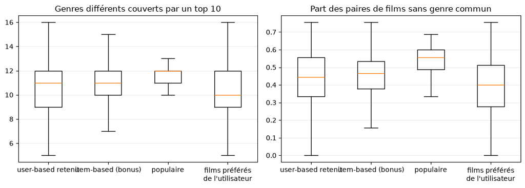

```python
# La même chose sur les 671 utilisateurs : une boîte par type de liste (moitié centrale, trait = médiane)
groupes = {**systemes, "films préférés de l'utilisateur": preferes}
valeurs = {nom: np.array([diversite(l) for l in listes.values() if l]) for nom, listes in groupes.items()}
fig, axes = plt.subplots(1, 2, figsize=(11, 4))
for ax, j, titre in ((axes[0], 0, "Genres différents couverts par un top 10"), (axes[1], 1, "Part des paires de films sans genre commun")):
    ax.boxplot([v[:, j][~np.isnan(v[:, j])] for v in valeurs.values()], showfliers=False)
    ax.set(xticks=range(1, 5), xticklabels=[n.replace(" de l'utilisateur", "\nde l'utilisateur") for n in valeurs], title=titre); ax.grid(axis="y", alpha=0.25)
plt.tight_layout()
```

**Réponse.** **Diverses en genres, mais pas plus que les goûts de l'utilisateur.** Un top 10 user-based couvre en moyenne 10,7 genres distincts et 43 % des paires de films de la liste n'ont aucun genre en commun. C'est presque exactement le profil des dix films préférés de l'utilisateur (10,3 genres, 39 %) : le système reproduit la variété de ses goûts, un peu plus. L'item-based fait pareil (11,0 et 44 %), et le top des ventes est le plus varié (11,6 et 54 %), parce qu'il mélange sans tenir compte de personne.

L'exemple de l'utilisateur 60 le montre : ses préférés vont du *Parrain* à *Castle in the Sky* ; son top 10 est cohérent, mais concentré sur le polar et le drame (sept films sur dix ont Crime ou Thriller, huit sur dix Drama) : les classiques du genre que ses voisins ont aimés. Diversité honnête à l'échelle des genres, faible à l'échelle des thèmes.

### 3) Les recommandations au global sont-elles diverses ?

*Diversité globale* (ou couverture) : sur les 671 listes, combien de films différents sont proposés, quelle part du catalogue cela représente, et à quel point les recommandations se concentrent sur quelques titres. Un système peut faire des listes variées pour chacun tout en proposant les mêmes cinquante films à tout le monde.

```python
# Couverture du catalogue et concentration des recommandations
def concentration(listes):
    comptes = pd.Series([f for l in listes.values() for f in l]).value_counts()
    cumul = comptes.cumsum() / comptes.sum()
    return pd.Series({"films distincts proposés": len(comptes),
                      "part du catalogue couverte": len(comptes) / len(n_avis),
                      "films qui font la moitié des recommandations": int((cumul < 0.5).sum() + 1),
                      "part prise par les 10 films les plus proposés": comptes.iloc[:10].sum() / comptes.sum()})
display(pd.DataFrame({nom: concentration(l) for nom, l in systemes.items()}).round(3))

# Les films les plus souvent proposés par le user-based, et à combien d'utilisateurs
plus_proposes = pd.Series([f for l in listes_ub.values() for f in l]).value_counts().head(5)
avec_titres(plus_proposes.to_frame("utilisateurs")).assign(avis_en_train=lambda d: n_avis.reindex(d.index.get_level_values(0)).to_numpy())
```

|  | user-based retenu | item-based (bonus) | populaire |
| --- | --- | --- | --- |
| films distincts proposés | 337.000 | 410.000 | 57.000 |
| part du catalogue couverte | 0.040 | 0.049 | 0.007 |
| films qui font la moitié des recommandations | 23.000 | 32.000 | 8.000 |
| part prise par les 10 films les plus proposés | 0.306 | 0.239 | 0.659 |

|  | titre | utilisateurs | avis_en_train |
| --- | --- | --- | --- |
| 318 | The Shawshank Redemption (1994) | 296 | 259 |
| 858 | The Godfather (1972) | 260 | 166 |
| 527 | Schindler's List (1993) | 257 | 200 |
| 296 | Pulp Fiction (1994) | 238 | 268 |
| 50 | The Usual Suspects (1995) | 219 | 164 |

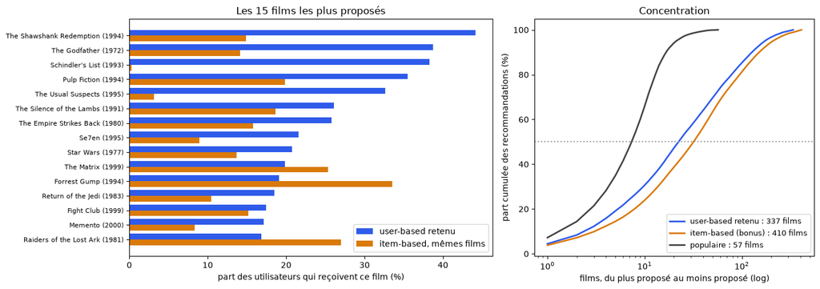

```python
# Les 15 films les plus proposés, et la part des utilisateurs qui les reçoivent ; puis la courbe de concentration
comptes_ub = pd.Series([f for l in listes_ub.values() for f in l]).value_counts()
comptes_ib = pd.Series([f for l in listes_ib.values() for f in l]).value_counts()
top15 = comptes_ub.head(15)
fig, axes = plt.subplots(1, 2, figsize=(14, 5), gridspec_kw={"width_ratios": [1.3, 1]})
y = np.arange(15)[::-1]
axes[0].barh(y + 0.2, top15.to_numpy() / len(utilisateurs) * 100, 0.4, color="#2F5BEA", label="user-based retenu")
axes[0].barh(y - 0.2, [comptes_ib.get(f, 0) / len(utilisateurs) * 100 for f in top15.index], 0.4, color="#D97A0B", label="item-based, mêmes films")
axes[0].set(yticks=y, yticklabels=titres.reindex(top15.index).fillna("?"), xlabel="part des utilisateurs qui reçoivent ce film (%)", title="Les 15 films les plus proposés")
axes[0].legend(loc="lower right"); axes[0].tick_params(axis="y", labelsize=8)
for (nom, l), c in zip(systemes.items(), ["#2F5BEA", "#D97A0B", "#444"]):
    comptes = pd.Series([f for films in l.values() for f in films]).value_counts()
    cumul = comptes.cumsum() / comptes.sum()
    axes[1].plot(range(1, len(cumul) + 1), cumul * 100, color=c, lw=2, label=f"{nom} : {len(comptes)} films")
axes[1].axhline(50, color="#999", ls=":"); axes[1].set(xscale="log", xlabel="films, du plus proposé au moins proposé (log)", ylabel="part cumulée des recommandations (%)", title="Concentration")
axes[1].legend(fontsize=9); plt.tight_layout()
```

|  | catalogue | user-based retenu | item-based (bonus) |
| --- | --- | --- | --- |
| Drama | 50.9 | 55.6 | 40.3 |
| Comedy | 37.3 | 13.8 | 28.9 |
| Thriller | 22.6 | 33.0 | 25.8 |
| Romance | 20.4 | 9.3 | 13.4 |
| Action | 19.7 | 29.1 | 36.1 |
| Crime | 14.1 | 34.2 | 21.3 |
| Adventure | 13.5 | 24.8 | 32.9 |
| Horror | 10.0 | 1.5 | 1.4 |
| Science Fiction | 9.7 | 16.6 | 21.8 |
| Family | 9.6 | 6.5 | 13.7 |
| Fantasy | 8.5 | 11.3 | 16.5 |
| Mystery | 7.3 | 11.3 | 9.9 |
| Animation | 4.8 | 2.6 | 6.6 |
| Music | 4.8 | 1.1 | 1.3 |

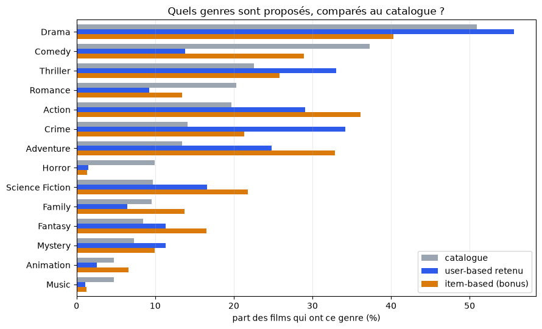

```python
# Par genre : part des films proposés qui portent chaque genre, comparée au catalogue
def part_genres(films):
    g = [genres_film.get(f) for f in films]; g = [x for x in g if isinstance(x, set)]
    return pd.Series([genre for ens in g for genre in ens]).value_counts() / len(g) * 100
genres = pd.DataFrame({"catalogue": part_genres(train["movieId"].unique()),
                       **{nom: part_genres([f for l in listes.values() for f in l]) for nom, listes in systemes.items() if nom != "populaire"}}).fillna(0)
genres = genres.sort_values("catalogue", ascending=False).head(14)
ax = genres.plot.barh(figsize=(9, 5.5), color=["#9aa5b1", "#2F5BEA", "#D97A0B"], width=0.75)
ax.invert_yaxis(); ax.set(xlabel="part des films qui ont ce genre (%)", title="Quels genres sont proposés, comparés au catalogue ?"); ax.grid(axis="x", alpha=0.25); plt.tight_layout()
genres.round(1)
```

**Réponse.** **Non.** Sur les 671 listes, le user-based ne propose que 337 films distincts, 4 % du catalogue, et 23 films suffisent à faire la moitié de toutes les recommandations ; les 10 films les plus proposés en représentent 31 %. *The Shawshank Redemption* est proposé à 296 utilisateurs sur 671, *The Godfather* à 260, *Schindler's List* à 257. C'est mieux que le top des ventes (57 films, 8 pour la moitié) et moins bien que l'item-based (410 films, 5 % du catalogue, 32 pour la moitié). Autrement dit, chaque liste est variée, mais toutes puisent dans le même petit réservoir de classiques : la conséquence directe du seuil de voisins. Les 96 % du catalogue restants ne sont jamais proposés à personne, quels que soient ses goûts.

Par genres, le même déséquilibre : le système sur-représente le polar et le drame (Crime passe de 14 % des films du catalogue à 34 % des films proposés, Thriller de 23 % à 33 %, Drama de 51 % à 56 %) et écrase la comédie (37 % → 14 %), la romance (20 % → 9 %), l'horreur (10 % → 1,5 %) et l'animation (5 % → 2,6 %). Lien avec le cours : le filtrage collaboratif a pour avantage une sérendipité naturelle et pour inconvénient le biais de popularité ; notre seuil de voisins amplifie le second et fait perdre la première, puisqu'un film inattendu est presque toujours un film peu vu. Au global, le système se comporte comme un top des ventes personnalisé, pas comme un système de découverte.

### 4) Les recommandations sont-elles réellement personnalisées ?

*Personnalisation* : deux utilisateurs aux goûts différents reçoivent-ils des listes différentes ? On mesure le nombre de films en commun entre les listes de deux utilisateurs, en moyenne sur toutes les paires, et le nombre de films en commun avec le top des ventes. Un système non personnalisé donnerait la même liste à tout le monde : 10 films en commun partout.

```python
# Films en commun entre deux listes (toutes les paires d'utilisateurs), et avec le top des ventes
def recouvrement(listes):
    ens = [set(l) for l in listes.values()]
    paires = [len(a & b) for i, a in enumerate(ens) for b in ens[i + 1:]]
    avec_pop = [len(set(l) & set(listes_pop[u])) for u, l in listes.items()]
    return pd.Series({"films en commun entre deux utilisateurs (moyenne)": np.mean(paires),
                      "paires d'utilisateurs sans aucun film en commun": np.mean(np.array(paires) == 0),
                      "films en commun avec le top des ventes": np.mean(avec_pop)})
display(pd.DataFrame({nom: recouvrement(l) for nom, l in systemes.items()}).round(2))

# Deux utilisateurs aux goûts opposés : celui qui note le plus haut et celui qui note le plus bas les films d'action
action = genres_film[genres_film.map(lambda g: isinstance(g, set) and "Action" in g)].index
note_action = train[train["movieId"].isin(action)].groupby("userId")["rating"].agg(["mean", "count"]).query("count >= 20")["mean"]
u_pour, u_contre = note_action.idxmax(), note_action.idxmin()
print(f"Utilisateur {u_pour} (note moyenne des films d'action {note_action[u_pour]:.2f}) et {u_contre} ({note_action[u_contre]:.2f}) : "
      f"{len(set(listes_ub[u_pour]) & set(listes_ub[u_contre]))} films en commun dans leurs top 10 user-based")
pd.DataFrame({f"utilisateur {u_pour}": avec_genres(listes_ub[u_pour])["titre"].to_numpy(),
              f"utilisateur {u_contre}": avec_genres(listes_ub[u_contre])["titre"].to_numpy()})
```

|  | user-based retenu | item-based (bonus) | populaire |
| --- | --- | --- | --- |
| films en commun entre deux utilisateurs (moyenne) | 1.49 | 1.12 | 5.42 |
| paires d'utilisateurs sans aucun film en commun | 0.28 | 0.43 | 0.01 |
| films en commun avec le top des ventes | 3.02 | 2.36 | 10.00 |

```
Utilisateur 298 (note moyenne des films d'action 4.61) et 457 (1.92) : 0 films en commun dans leurs top 10 user-based
```

|  | utilisateur 298 | utilisateur 457 |
| --- | --- | --- |
| 0 | The Shawshank Redemption (1994) | The Godfather (1972) |
| 1 | Pulp Fiction (1994) | The Godfather: Part II (1974) |
| 2 | Fight Club (1999) | GoodFellas (1990) |
| 3 | Return of the Jedi (1983) | Schindler's List (1993) |
| 4 | Donnie Darko (2001) | The Lord of the Rings: The Fellowship of the Ring (2001) |
| 5 | Saving Private Ryan (1998) | Memento (2000) |
| 6 | Forrest Gump (1994) | High Fidelity (2000) |
| 7 | Se7en (1995) | 2001: A Space Odyssey (1968) |
| 8 | The Lord of the Rings: The Return of the King (2003) | The Princess Bride (1987) |
| 9 | The Empire Strikes Back (1980) | Blade Runner (1982) |

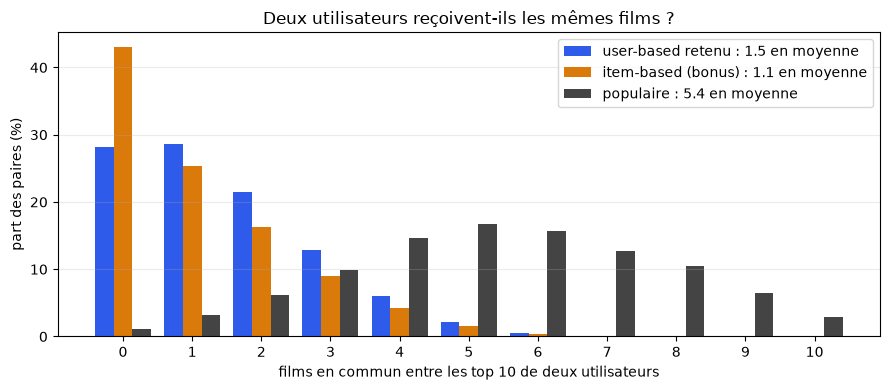

```python
# Pour chaque nombre de films en commun entre deux utilisateurs, la part des paires
fig, ax = plt.subplots(figsize=(9, 4)); w = 0.27
for i, ((nom, l), c) in enumerate(zip(systemes.items(), ["#2F5BEA", "#D97A0B", "#444"])):
    ens = [set(x) for x in l.values()]
    communs = np.array([len(a & b) for j, a in enumerate(ens) for b in ens[j + 1:]])
    ax.bar(np.arange(11) + (i - 1) * w, np.bincount(communs, minlength=11) / len(communs) * 100, w, color=c, label=f"{nom} : {communs.mean():.1f} en moyenne")
ax.set(xticks=range(11), xlabel="films en commun entre les top 10 de deux utilisateurs", ylabel="part des paires (%)", title="Deux utilisateurs reçoivent-ils les mêmes films ?")
ax.legend(); ax.grid(axis="y", alpha=0.25); plt.tight_layout()
```

**Réponse.** **Oui, mais moins qu'on ne le croirait.** Deux utilisateurs pris au hasard ont en moyenne 1,5 film en commun dans leurs top 10, et 28 % des paires n'en ont aucun ; le top des ventes, identique pour tous à quelques films vus près, en a 5,4. Mais 3,0 des 10 films d'une liste viennent du top des ventes : trois dixièmes de chaque liste sont communs à tout le monde, sept dixièmes sont propres à l'utilisateur. L'item-based est plus personnalisé (1,1 film en commun, 43 % des paires sans aucun).

L'exemple le confirme : l'utilisateur 298, qui adore les films d'action (note moyenne 4,6), et le 457, qui les déteste (1,9), n'ont aucun film en commun. Le premier reçoit *Fight Club*, *Star Wars*, *Se7en*, *Il faut sauver le soldat Ryan* ; le second *Le Parrain*, *Memento*, *2001*, *Blade Runner*. Les deux reçoivent un *Seigneur des anneaux*, mais pas le même. Les listes suivent les goûts, dans les limites d'un réservoir de films populaires.

### 5) Comment améliorer le système en production ?

**Réponse.** Dans l'ordre de ce que les mesures du TP justifient.

1. **Changer de système, ou combiner.** L'item-based avec classement par somme fait mieux sur tout : NDCG 0,249 contre 0,201, RMSE 0,915 contre 1,011, films moins populaires et 410 films distincts contre 337 (exercice 4, bonus). Il est aussi plus explicable, « parce que vous avez aimé *Le Parrain* » (cours, page 26). Le user-based garde un intérêt : des listes différentes, donc un *hybride* par pondération ou par mélange des deux listes (cours, page 38) est la première chose à tester.
2. **Prédire les notes avec un modèle.** Si l'application affiche des notes prédites, le user-based brut est le pire choix (moins bon que la moyenne de l'utilisateur). Le centrage donne 0,947, l'item-based 0,915, et la *factorisation matricielle* du cours (page 44), qui apprend un vecteur par utilisateur et par film, fait mieux encore sur ce jeu de données d'après les résultats publiés. C'est la réponse à « comment intégrer du machine learning » (cours, page 19).
3. **Tempérer la popularité.** 96 % du catalogue n'est jamais proposé (question 3). Deux leviers simples : pénaliser le score des films très vus, ou réserver une partie de la liste à des films moins connus proposés par l'item-based, en mesurant la couverture et la diversité à côté du NDCG, comme on l'a fait ici.
4. **Le démarrage à froid.** Un nouvel utilisateur sans avis ou un nouveau film sans note ne peuvent rien recevoir du filtrage collaboratif. Le catalogue a des genres, des résumés, des acteurs : un filtrage par contenu (cours, page 28) prend le relais pour eux, en commutation (cours, page 38).
5. **Mesurer comme en vrai.** Notre découpage cache des avis au hasard ; en production on prédit l'avenir, donc il faudrait cacher les avis les plus récents (les timestamps existent). Et la seule mesure finale est le *test A/B* (cours, page 47) : une partie des utilisateurs reçoit le nouveau système, et on compare ce qu'ils regardent vraiment, y compris des signaux implicites (visionnage, temps passé) plutôt que des notes.
6. **Le passage à l'échelle.** Une matrice de similarité 671 × 671 se recalcule en une seconde ; avec des millions d'utilisateurs, il faut des matrices creuses, un recalcul périodique plutôt qu'à chaque requête, et des listes précalculées. L'item-based a l'avantage que la similarité entre films change lentement.